# R Uygulamalı Veri Bilimi

Ümit Mert Çağlar

2025-02-24

# R Uygulamalı Veri Bilimi

## Ümit Mert Çağlar

- ODTÜ Enformatik Enstitüsü (2024-)
  - Modelleme ve Simülasyon Araştırma Görevlisi
- TUSAŞ Yapay Zeka Mühendisliği (2019-2024)
  - Teknik Ekip Lideri
  - Yazılım Tasarım Mühendisi
- STM (2019-2019)
  - Sistem Mühendisi
- ODTÜ Enformatik Enstitüsü
  - Yüksek Lisans (2018-2021)
  - Doktora (2021-)
- ODTÜ Elektrik-Elektronik Mühendisliği (2017)

# Eğitim İzlencesi

1. R ve Veri Bilimine Giriş
2. Veri Okuma ve Temizleme
3. Veri Dönüşümleri ve Manipülasyonlar
4. Veri Analizleri ve İstatistiksel Yaklaşımlar
5. Veri Görselleştirme
6. Sonuçları Raporlama ve Sunumlar
7. Uygulamalı çalışmalar ve Vaka Analizleri

# 1. Giriş

- R dilinin veri analizinde kullanımı ve avantajları
- RStudio arayüzü: Script, konsol, environment ve plot pencereleri
- Temel R komutları, veri tipleri, değişkenler ve temel işlemler
- Paket yönetimi: CRAN’dan paket yükleme ve güncelleme

# 1.1 R dilinin veri analizinde kullanımı ve avantajları

| Araç | Güçlü Yanları | Olumsuz Özellikleri |
| --- | --- | --- |
| Excel | Çok kolay kullanım Basit arayüz | Maliyetli Yavaş Bir şirkete bağlı Kapalı kaynak Çok kısıtlı programlama |
| Matlab | Şirket desteği Kolay kullanım Dokümantasyon Arayüz | Çok maliyetli Yavaş Bir şirkete bağlı Kısmen kapalı kaynak Kısıtlı programlama |
| Python | Açık kaynak topluluğu Ücretsiz Çok geniş kullanım alanı Yapay Zeka Topluluk destekli arayüz | Açık kaynak topluluğu Geliştirme ortamı sorunları Sadece topluluk desteği Dokümantasyon |
| R | Açık kaynak topluluğu Ücretsiz İstatistik ve veri bilimi Dokümantasyon Topluluk destekli arayüz | Sadece topluluk desteği Kısıtlı kullanım alanı |

# 1.2 RStudio Arayüzü

| Geliştirme Penceresi R Markdown R Notebook R Script Veya diğer diller (SQL, Python, C++ vb.) | Değişkenler Bağlantılar Ortam değerleri |
| --- | --- |
| Konsol Terminal Render Arkaplan işleri | Dosyalar Grafikler Paketler Yardım Sunum Dokümanlar |

# 1.3 Temel R Komutları, Veri Tipleri, Değişkenler

## Nesne Tabanlı Programlama

- Nesne Tabanlı Programlama
- Sınıf Oluşturma
- Metod Tanımlama
- Yeni Nesne Oluşturma

R programlama dili, genellikle istatistiksel hesaplamalar ve veri analizi için kullanılan bir dildir. R, nesne tabanlı programlama (OOP) konusunda diğer diller kadar gelişmiş olmasa da, bazı nesne tabanlı programlama özelliklerini destekler.

## Sınıf Oluşturma

Bir liste oluştur ve sınıf ismini “kişi” olarak ata

```r
# Bir liste oluştur ve sınıf ismini "kişi" olarak ata
kişi <- list(adı = "Ali", yaşı = 30)
class(kişi) <- "kişi"

# Sınıfı kontrol et
class(kişi)
```

```
## [1] "kişi"
```

## Metod Tanımlama

print metodunu person sınıfı için özelleştir

```r
# print metodunu person sınıfı için özelleştir
print.kişi <- function(nesne) {
  cat("Adı:", nesne$adı, "\n")
  cat("Yaşı:", nesne$yaşı, "\n")
}

# print fonksiyonunu çağır
print(kişi)
```

```
## Adı: Ali
## Yaşı: 30
```

## Yeni Nesne Oluşturma

Yeni bir kişi nesnesi oluştur, var olan kişi nesnesinin fonksiyonu bu nesnede de geçerli olur.(Inheritance-Miras)

```r
# Yeni bir kişi nesnesi oluştur
yeni_kişi <- list(adı = "Ayşe", yaşı = 25)
class(yeni_kişi) <- "kişi"

# print metodunu çağır
print(yeni_kişi)
```

```
## Adı: Ayşe
## Yaşı: 25
```

## Yardım

- `?max`: max fonksiyonu için yardım belgelerini gösterir
- `?tidyverse`: tidyverse paketinin belgelerini gösterir
- `??"max"`: Belirli bir girdiyle ilişkili belgeleri döndürür
- `str(my_df)`: Belirli bir nesnenin yapısını ve bilgilerini döndürür
- `class(my_df)`: Verilen nesnenin sınıfını döndürür

## Sayısal İşlemler

| **Operatör** | **Tanım** |
| --- | --- |
| `a + b` | İki değişkeni toplar |
| `a - b` | İki değişkeni çıkarır |
| `a * b` | İki değişkeni çarp |
| `a / b` | İki değişkeni böl |
| `a ^ b` | Bir değişkenin üsselleştirilmesi |
| `a %% b` | Bir değişkenin kalanı |
| `a %/% b` | Değişkenlerin tam sayı bölümü |

## Mantıksal İşlemler

| **Operatör** | **Tanım** |
| --- | --- |
| `!` | Mantıksal DEĞİL |
| `&` | Öğe bazında Mantıksal VE |
| `&&` | Mantıksal VE |
| `\|` | Öğe bazında Mantıksal VEYA |
| `\|\|` | Mantıksal VEYA |

## İlişkisel İşlemler

| **Operatör** | **Tanım** |
| --- | --- |
| `a == b` | Eşitlik testleri |
| `a != b` | Eşitsizlik testleri |
| `a > b` | Daha büyük testler |
| `a < b` | Daha küçük testler |
| `a >= b` | Daha büyük veya eşit için testler |
| `a <= b` | Daha küçük veya eşit için testler |

## Atama

| **Operatör** | **Tanım** |
| --- | --- |
| `x <- 1` `x = 1` | x’e bir değişken atar |

## Vektör

| **Giriş** | **Çıktı** | **Tanım** |
| --- | --- | --- |
| `c(1,3,5)` | `1 3 5` | Virgülle ayrılmış öğeleri kullanarak bir vektör oluşturur |
| `1:7` | `1 2 3 4 5 6 7` | İki sayı arasında tam sayılardan oluşan bir vektör oluşturur |
| `seq(2,8,by = 2)` | `2 4 6 8` | İki sayı arasında, her bir eleman arasında belirtilen bir aralık olacak şekilde bir vektör oluşturur. |
| `rep(2,8,times = 4)` | `2 8 2 8 2 8 2 8` | Belirli sayıda tekrarlanan verilen elemanlardan oluşan bir vektör oluşturur. |
| `rep(2,8,each = 3)` | `2 2 2 8 8 8` | Verilen öğelerin her birini belirli sayıda tekrarlayan bir vektör oluşturur. |

## Vektör Fonksiyonları

- `sort(my_vector)`: Sıralanmış olarak döner
- `rev(my_vector)`: Sırasını tersine çevirir
- `table(my_vector)`: Bir vektördeki değerleri say
- `unique(my_vector)`: Bir vektördeki farklı elemanlar

## Vektör Elemanlarına Erişim

- `my_vector[6]`: Altıncı öğeyi döndürür
- `my_vector[-6]`: Altıncı öğe hariç tümünü döndürür
- `my_vector[2:6]`: İki ila altı arasındaki öğeleri döndürür
- `my_vector[-(2:6)]`: İkinci ve altıncı arasındakiler hariç tüm öğeleri döndürür
- `my_vector[c(2,6)]`: İkinci ve altıncı öğeleri döndürür
- `my_vector[my_vector == 5]`: `5`’e eşit öğeleri döndürür
- `my_vector[my_vector < 5 ]`: `5`’den küçük öğeleri döndürür
- `my_vector[my_vector %in% c(2, 5 ,8 )]`: `{2, 5, 8}` Kümesindeki öğeleri döndürür

## Matematiksel Fonksiyonlar

- `log(x)`: Bir değişkenin logaritmasını döndürür
- `exp(x)`: Bir değişkenin üstel değerini döndürür
- `max(x)`: Bir vektörün maksimum değerini döndürür
- `min(x)`: Bir vektörün en küçük değerini döndürür
- `mean(x)`: Bir vektörün ortalamasını döndürür
- `sum(x)`: Bir vektörün toplamını döndürür
- `median(x)`: Bir vektörün medyanını döndürür
- `quantile(x)`: Bir vektörün yüzdelik dilimleri
- `round(x, n)`: n ondalık basamağa yuvarla
- `rank(x)`: Bir vektördeki elemanların sıralaması
- `signif(x, n)`: Anlamlı rakamları yuvarlayın
- `var(x)`: Bir vektörün varyansı
- `cor(x, y)`: İki vektör arasındaki korelasyon
- `sd(x)`: Bir vektörün standart sapması

# 1.4 Paketler

- `install.packages(“tidyverse”)`: Yeni paketler yüklemenizi sağlar (örneğin, tidyverse paketi)
- `library(tidyverse)`: Paketleri yüklemenizi ve kullanmanızı sağlar (örneğin, tidyverse paketi)
- RStudio Paketler arayüzünden de yükleme ve güncelleme yapabilirsiniz

## Örnek çalışma

```r
# Gerekli kütüphaneleri yükleme
library(tidyverse)
# Verisetini yükleme (mtcars)
data <- mtcars

# İlk birkaç satıra bakma
head(data)
```

```
##                    mpg cyl disp  hp drat    wt  qsec vs am gear carb
## Mazda RX4         21.0   6  160 110 3.90 2.620 16.46  0  1    4    4
## Mazda RX4 Wag     21.0   6  160 110 3.90 2.875 17.02  0  1    4    4
## Datsun 710        22.8   4  108  93 3.85 2.320 18.61  1  1    4    1
## Hornet 4 Drive    21.4   6  258 110 3.08 3.215 19.44  1  0    3    1
## Hornet Sportabout 18.7   8  360 175 3.15 3.440 17.02  0  0    3    2
## Valiant           18.1   6  225 105 2.76 3.460 20.22  1  0    3    1
```

```r
# Özet istatistikler
summary(data)
```

```
##       mpg             cyl             disp             hp
##  Min.   :10.40   Min.   :4.000   Min.   : 71.1   Min.   : 52.0
##  1st Qu.:15.43   1st Qu.:4.000   1st Qu.:120.8   1st Qu.: 96.5
##  Median :19.20   Median :6.000   Median :196.3   Median :123.0
##  Mean   :20.09   Mean   :6.188   Mean   :230.7   Mean   :146.7
##  3rd Qu.:22.80   3rd Qu.:8.000   3rd Qu.:326.0   3rd Qu.:180.0
##  Max.   :33.90   Max.   :8.000   Max.   :472.0   Max.   :335.0
##       drat             wt             qsec             vs
##  Min.   :2.760   Min.   :1.513   Min.   :14.50   Min.   :0.0000
##  1st Qu.:3.080   1st Qu.:2.581   1st Qu.:16.89   1st Qu.:0.0000
##  Median :3.695   Median :3.325   Median :17.71   Median :0.0000
##  Mean   :3.597   Mean   :3.217   Mean   :17.85   Mean   :0.4375
##  3rd Qu.:3.920   3rd Qu.:3.610   3rd Qu.:18.90   3rd Qu.:1.0000
##  Max.   :4.930   Max.   :5.424   Max.   :22.90   Max.   :1.0000
##        am              gear            carb
##  Min.   :0.0000   Min.   :3.000   Min.   :1.000
##  1st Qu.:0.0000   1st Qu.:3.000   1st Qu.:2.000
##  Median :0.0000   Median :4.000   Median :2.000
##  Mean   :0.4062   Mean   :3.688   Mean   :2.812
##  3rd Qu.:1.0000   3rd Qu.:4.000   3rd Qu.:4.000
##  Max.   :1.0000   Max.   :5.000   Max.   :8.000
```

```r
# Eksik değer var mı?
sum(is.na(data))
```

```
## [1] 0
```

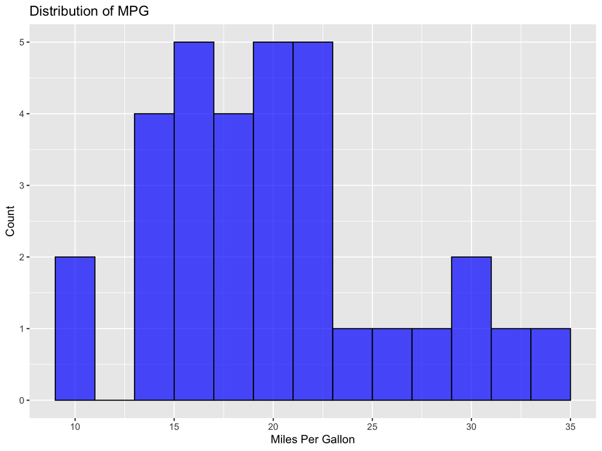

```r
# Veri görselleştirme
# MPG Histogramı
ggplot(data, aes(x = mpg)) +
  geom_histogram(binwidth = 2, fill = 'blue', color = 'black', alpha = 0.7) +
  labs(title = 'Distribution of MPG', x = 'Miles Per Gallon', y = 'Count')
```

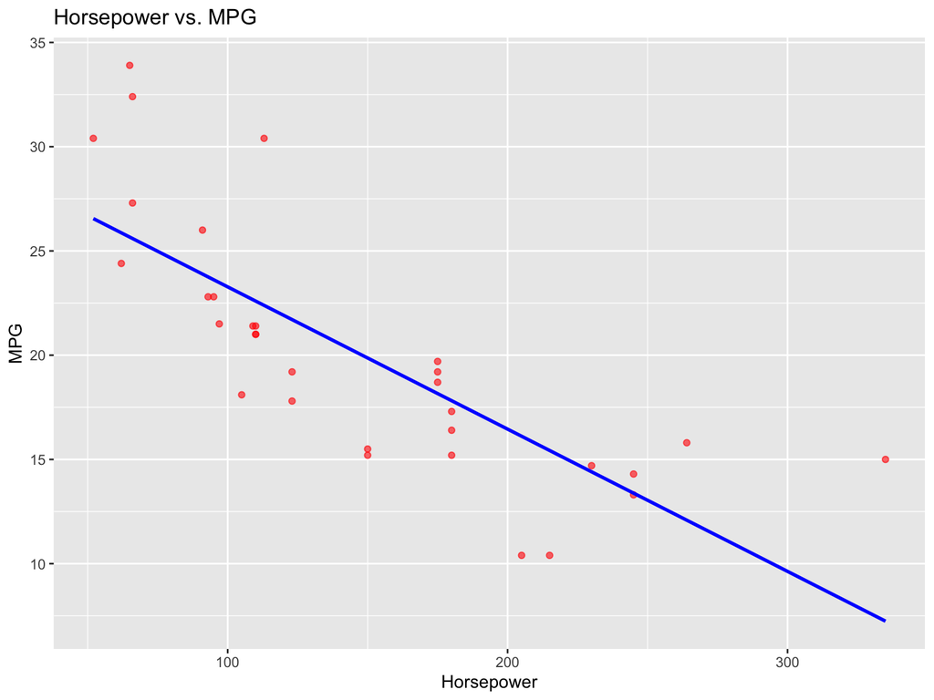

```r
# Scatter plot of Horsepower vs. MPG
ggplot(data, aes(x = hp, y = mpg)) +
  geom_point(color = 'red', alpha = 0.6) +
  geom_smooth(method = 'lm', color = 'blue', se = FALSE) +
  labs(title = 'Horsepower vs. MPG', x = 'Horsepower', y = 'MPG')
```

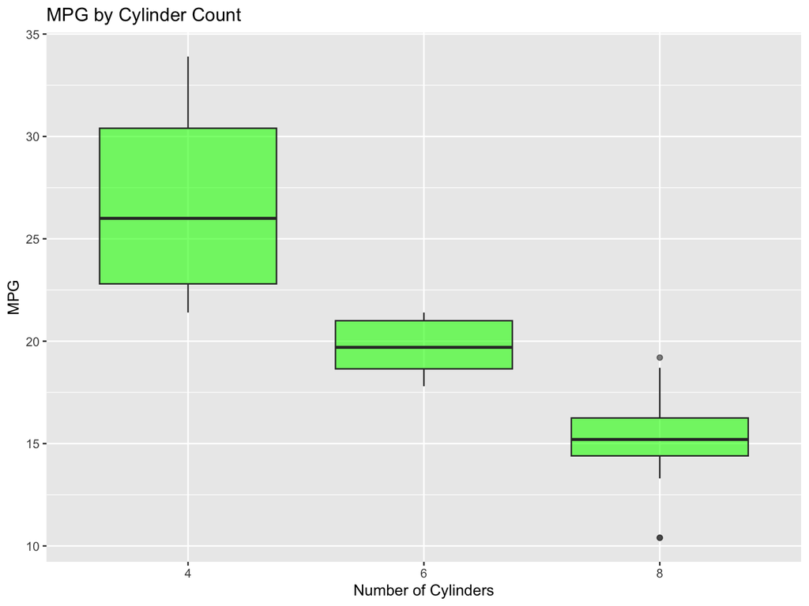

```r
# Boxplot of MPG by Cylinder Count
ggplot(data, aes(x = factor(cyl), y = mpg)) +
  geom_boxplot(fill = 'green', alpha = 0.6) +
  labs(title = 'MPG by Cylinder Count', x = 'Number of Cylinders', y = 'MPG')
```

```r
# Correlation matrix
cor_matrix <- cor(data)
print(cor_matrix)
```

```
##             mpg        cyl       disp         hp        drat         wt
## mpg   1.0000000 -0.8521620 -0.8475514 -0.7761684  0.68117191 -0.8676594
## cyl  -0.8521620  1.0000000  0.9020329  0.8324475 -0.69993811  0.7824958
## disp -0.8475514  0.9020329  1.0000000  0.7909486 -0.71021393  0.8879799
## hp   -0.7761684  0.8324475  0.7909486  1.0000000 -0.44875912  0.6587479
## drat  0.6811719 -0.6999381 -0.7102139 -0.4487591  1.00000000 -0.7124406
## wt   -0.8676594  0.7824958  0.8879799  0.6587479 -0.71244065  1.0000000
## qsec  0.4186840 -0.5912421 -0.4336979 -0.7082234  0.09120476 -0.1747159
## vs    0.6640389 -0.8108118 -0.7104159 -0.7230967  0.44027846 -0.5549157
## am    0.5998324 -0.5226070 -0.5912270 -0.2432043  0.71271113 -0.6924953
## gear  0.4802848 -0.4926866 -0.5555692 -0.1257043  0.69961013 -0.5832870
## carb -0.5509251  0.5269883  0.3949769  0.7498125 -0.09078980  0.4276059
##             qsec         vs          am       gear        carb
## mpg   0.41868403  0.6640389  0.59983243  0.4802848 -0.55092507
## cyl  -0.59124207 -0.8108118 -0.52260705 -0.4926866  0.52698829
## disp -0.43369788 -0.7104159 -0.59122704 -0.5555692  0.39497686
## hp   -0.70822339 -0.7230967 -0.24320426 -0.1257043  0.74981247
## drat  0.09120476  0.4402785  0.71271113  0.6996101 -0.09078980
## wt   -0.17471588 -0.5549157 -0.69249526 -0.5832870  0.42760594
## qsec  1.00000000  0.7445354 -0.22986086 -0.2126822 -0.65624923
## vs    0.74453544  1.0000000  0.16834512  0.2060233 -0.56960714
## am   -0.22986086  0.1683451  1.00000000  0.7940588  0.05753435
## gear -0.21268223  0.2060233  0.79405876  1.0000000  0.27407284
## carb -0.65624923 -0.5696071  0.05753435  0.2740728  1.00000000
```

```r
# İşlenmiş veriyi kaydetme
write.csv(data, 'cleaned_data.csv', row.names = FALSE)
```

## Örnek Çalışma 2

### Kütüphaneler

```r
# Load the libraries
library(tidyverse)
library(ggplot2)
library(dplyr)
library(readr)
```

### Veri

```r
# Load a dataset (for example, the built-in 'mtcars' dataset)
data(mtcars)

# Alternatively, you can load your own dataset from a CSV file
# mtcars <- read_csv("path_to_your_file.csv")

# View the first few rows of the dataset
head(mtcars)
```

```
##                    mpg cyl disp  hp drat    wt  qsec vs am gear carb
## Mazda RX4         21.0   6  160 110 3.90 2.620 16.46  0  1    4    4
## Mazda RX4 Wag     21.0   6  160 110 3.90 2.875 17.02  0  1    4    4
## Datsun 710        22.8   4  108  93 3.85 2.320 18.61  1  1    4    1
## Hornet 4 Drive    21.4   6  258 110 3.08 3.215 19.44  1  0    3    1
## Hornet Sportabout 18.7   8  360 175 3.15 3.440 17.02  0  0    3    2
## Valiant           18.1   6  225 105 2.76 3.460 20.22  1  0    3    1
```

### Veri keşfi

```r
# Get a summary of the dataset
summary(mtcars)
```

```
##       mpg             cyl             disp             hp
##  Min.   :10.40   Min.   :4.000   Min.   : 71.1   Min.   : 52.0
##  1st Qu.:15.43   1st Qu.:4.000   1st Qu.:120.8   1st Qu.: 96.5
##  Median :19.20   Median :6.000   Median :196.3   Median :123.0
##  Mean   :20.09   Mean   :6.188   Mean   :230.7   Mean   :146.7
##  3rd Qu.:22.80   3rd Qu.:8.000   3rd Qu.:326.0   3rd Qu.:180.0
##  Max.   :33.90   Max.   :8.000   Max.   :472.0   Max.   :335.0
##       drat             wt             qsec             vs
##  Min.   :2.760   Min.   :1.513   Min.   :14.50   Min.   :0.0000
##  1st Qu.:3.080   1st Qu.:2.581   1st Qu.:16.89   1st Qu.:0.0000
##  Median :3.695   Median :3.325   Median :17.71   Median :0.0000
##  Mean   :3.597   Mean   :3.217   Mean   :17.85   Mean   :0.4375
##  3rd Qu.:3.920   3rd Qu.:3.610   3rd Qu.:18.90   3rd Qu.:1.0000
##  Max.   :4.930   Max.   :5.424   Max.   :22.90   Max.   :1.0000
##        am              gear            carb
##  Min.   :0.0000   Min.   :3.000   Min.   :1.000
##  1st Qu.:0.0000   1st Qu.:3.000   1st Qu.:2.000
##  Median :0.0000   Median :4.000   Median :2.000
##  Mean   :0.4062   Mean   :3.688   Mean   :2.812
##  3rd Qu.:1.0000   3rd Qu.:4.000   3rd Qu.:4.000
##  Max.   :1.0000   Max.   :5.000   Max.   :8.000
```

```r
# Check the structure of the dataset
str(mtcars)
```

```
## 'data.frame':    32 obs. of  11 variables:
##  $ mpg : num  21 21 22.8 21.4 18.7 18.1 14.3 24.4 22.8 19.2 ...
##  $ cyl : num  6 6 4 6 8 6 8 4 4 6 ...
##  $ disp: num  160 160 108 258 360 ...
##  $ hp  : num  110 110 93 110 175 105 245 62 95 123 ...
##  $ drat: num  3.9 3.9 3.85 3.08 3.15 2.76 3.21 3.69 3.92 3.92 ...
##  $ wt  : num  2.62 2.88 2.32 3.21 3.44 ...
##  $ qsec: num  16.5 17 18.6 19.4 17 ...
##  $ vs  : num  0 0 1 1 0 1 0 1 1 1 ...
##  $ am  : num  1 1 1 0 0 0 0 0 0 0 ...
##  $ gear: num  4 4 4 3 3 3 3 4 4 4 ...
##  $ carb: num  4 4 1 1 2 1 4 2 2 4 ...
```

```r
# Check for missing values
sum(is.na(mtcars))
```

```
## [1] 0
```

```r
# Get the dimensions of the dataset (rows x columns)
dim(mtcars)
```

```
## [1] 32 11
```

```r
# Get the column names
colnames(mtcars)
```

```
##  [1] "mpg"  "cyl"  "disp" "hp"   "drat" "wt"   "qsec" "vs"   "am"   "gear"
## [11] "carb"
```

### Veri temizleme

```r
# Example: Replace missing values with the mean (if any)
mtcars <- mtcars %>%
  mutate(across(everything(), ~ ifelse(is.na(.), mean(., na.rm = TRUE), .)))

# Check again for missing values
sum(is.na(mtcars))
```

```
## [1] 0
```

### Veri görselleştirme

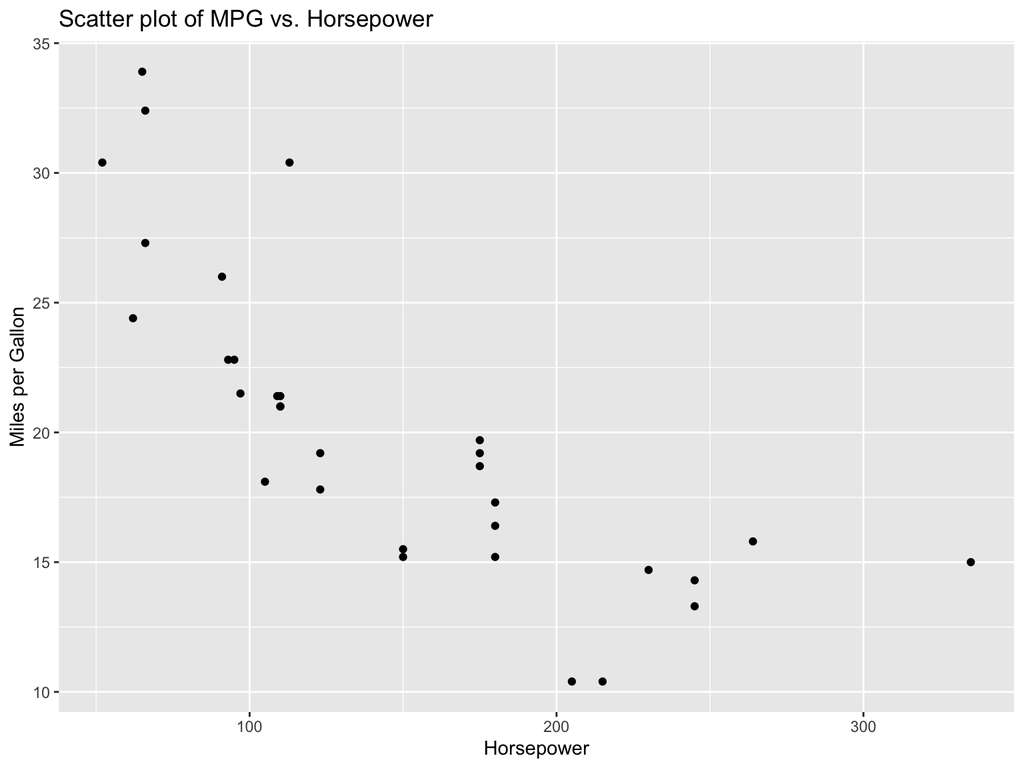

```r
# Scatter plot of mpg vs. hp
ggplot(mtcars, aes(x = hp, y = mpg)) +
  geom_point() +
  labs(title = "Scatter plot of MPG vs. Horsepower",
       x = "Horsepower",
       y = "Miles per Gallon")
```

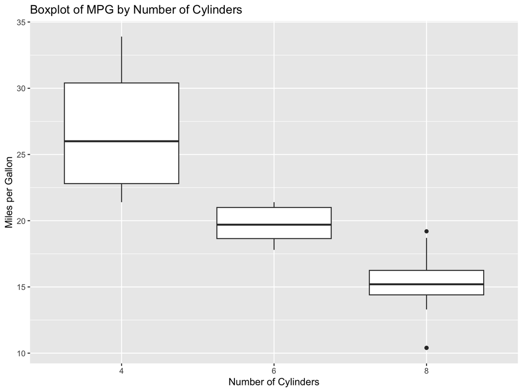

```r
# Boxplot of mpg by number of cylinders
ggplot(mtcars, aes(x = as.factor(cyl), y = mpg)) +
  geom_boxplot() +
  labs(title = "Boxplot of MPG by Number of Cylinders",
       x = "Number of Cylinders",
       y = "Miles per Gallon")
```

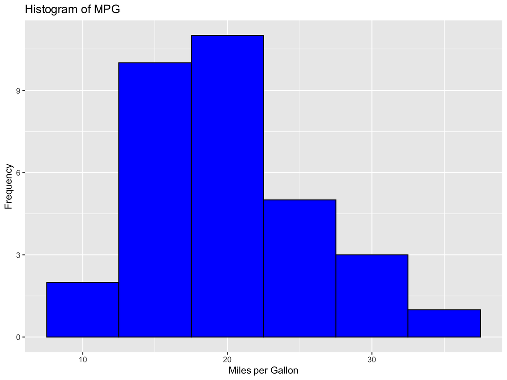

```r
# Histogram of mpg
ggplot(mtcars, aes(x = mpg)) +
  geom_histogram(binwidth = 5, fill = "blue", color = "black") +
  labs(title = "Histogram of MPG",
       x = "Miles per Gallon",
       y = "Frequency")
```

### Temel istatistiksel analizler

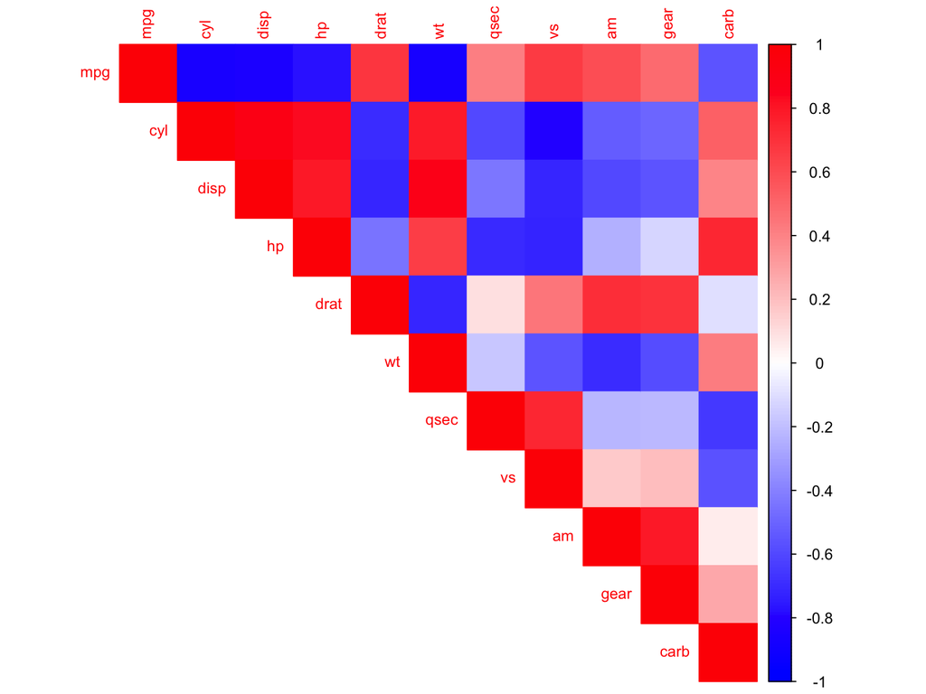

```r
# Correlation matrix

# Load the package
library(corrplot)
# Compute correlation matrix
cor_matrix <- cor(mtcars)

# Visualize the correlation matrix
corrplot(cor_matrix, method = "color", type = "upper", tl.cex = 0.8, col = colorRampPalette(c("blue", "white", "red"))(200))
```

```r
# Linear regression model: mpg as a function of hp and wt
model <- lm(mpg ~ hp + wt, data = mtcars)
summary(model)
```

```
##
## Call:
## lm(formula = mpg ~ hp + wt, data = mtcars)
##
## Residuals:
##    Min     1Q Median     3Q    Max
## -3.941 -1.600 -0.182  1.050  5.854
##
## Coefficients:
##             Estimate Std. Error t value Pr(>|t|)
## (Intercept) 37.22727    1.59879  23.285  < 2e-16 ***
## hp          -0.03177    0.00903  -3.519  0.00145 **
## wt          -3.87783    0.63273  -6.129 1.12e-06 ***
## ---
## Signif. codes:  0 '***' 0.001 '**' 0.01 '*' 0.05 '.' 0.1 ' ' 1
##
## Residual standard error: 2.593 on 29 degrees of freedom
## Multiple R-squared:  0.8268, Adjusted R-squared:  0.8148
## F-statistic: 69.21 on 2 and 29 DF,  p-value: 9.109e-12
```

```r
# ANOVA ile farklı silindir gruplarını mpg ortalamasıyla karşılaştırma
anova_result <- aov(mpg ~ as.factor(cyl), data = mtcars)
summary(anova_result)
```

```
##                Df Sum Sq Mean Sq F value   Pr(>F)
## as.factor(cyl)  2  824.8   412.4    39.7 4.98e-09 ***
## Residuals      29  301.3    10.4
## ---
## Signif. codes:  0 '***' 0.001 '**' 0.01 '*' 0.05 '.' 0.1 ' ' 1
```

### İşlenmiş veriyi kaydetme

```r
# İşlenmiş veriyi başka bir dosyaya kaydetme
write_csv(mtcars, "cleaned_mtcars.csv")
```

### Raporlama ve sunuş

R markdon ile dinamik raporlama yapabilir, kod, görselleştirme ve analizleri bir arada sunabilirsiniz.

# 2. Veri İçe Aktarma ve Temizleme

- Farklı veri biçimleri
  - Veri BiçimlerininTanıtımı (CSV, Excel, JSON, SQL veri tabanları)
  - Verilerin R ortamına aktarılması ve analiz öncesi veri hazırlama
  - readr, readxl gibi paketlerle veri okuma
  - Veri yapılarının incelenmesi: data.frame, tibble ve listeler
- Veri temizleme teknikleri
  - Eksik değerlerin, aykırı değerlerin tespiti ve yönetimi
  - Veri tiplerinin dönüştürülmesi ve format ayarlamaları
  - Dönüşümler ve filtreleme işlemleri (ör. dplyr ile)

# 2.1 Veri Biçimleri

```r
# Gerekli kütüphaneleri yükleme
library(readr)
library(writexl)
library(jsonlite)
library(readxl)

# Basit bir veri çerçevesi oluşturma
veri <- data.frame(
  ID = c(1, 2, 3),
  Isim = c("Ali", "Ayşe", "Mehmet"),
  Yas = c(25, 30, 35)
)

# CSV dosyası oluşturma ve okuma
write_csv(veri, "ornek_veri.csv")
cat("CSV dosyası oluşturuldu.\n")
```

```
## CSV dosyası oluşturuldu.
```

```r
okunan_csv <- read_csv("ornek_veri.csv")
print(okunan_csv)
```

```
## # A tibble: 3 × 3
##      ID Isim     Yas
##   <dbl> <chr>  <dbl>
## 1     1 Ali       25
## 2     2 Ayşe      30
## 3     3 Mehmet    35
```

```r
# Excel dosyası oluşturma ve okuma
write_xlsx(veri, "ornek_veri.xlsx")
cat("Excel dosyası oluşturuldu.\n")
```

```
## Excel dosyası oluşturuldu.
```

```r
okunan_excel <- read_excel("ornek_veri.xlsx")
print(okunan_excel)
```

```
## # A tibble: 3 × 3
##      ID Isim     Yas
##   <dbl> <chr>  <dbl>
## 1     1 Ali       25
## 2     2 Ayşe      30
## 3     3 Mehmet    35
```

```r
# JSON dosyası oluşturma ve okuma
write_json(veri, "ornek_veri.json", pretty = TRUE)
cat("JSON dosyası oluşturuldu.\n")
```

```
## JSON dosyası oluşturuldu.
```

```r
okunan_json <- fromJSON("ornek_veri.json")
print(okunan_json)
```

```
##   ID   Isim Yas
## 1  1    Ali  25
## 2  2   Ayşe  30
## 3  3 Mehmet  35
```

```r
# CSV dosyasını silme
unlink("ornek_veri.csv")
cat("ornek_veri.csv dosyası silindi.\n")
```

```
## ornek_veri.csv dosyası silindi.
```

```r
# Excel dosyasını silme
unlink("ornek_veri.xlsx")
cat("ornek_veri.xlsx dosyası silindi.\n")
```

```
## ornek_veri.xlsx dosyası silindi.
```

```r
# JSON dosyasını silme
unlink("ornek_veri.json")
cat("ornek_veri.json dosyası silindi.\n")
```

```
## ornek_veri.json dosyası silindi.
```

## SQL

SQL veritabanlarından veri çekmek için kullanılan bir sorgulama dilidir. Bu dil sayesinde istenen kriterlere uygun, çeşitli veritabanlarından birleştirmeler gibi özelliklerle beraber veri çekilebilir. R dilinde de SQL veritabanlarından veri çekmek, veri yazmak ve kaydetmek mümkündür.

Öncelikle gerekli kütüphaneleri yükleyerek başlıyoruz.

```r
library(odbc) #Veritabanına bağlanmak için gereken sürücüler
library(DBI) #Veritabanıyla iletişim kurmak için gerekenler
library(RSQL) #SQL sorgularını R dilinde koşmak için gereken kütüphane
library(RSQLite) #Yerel bir SQL veritabanı oluşturmak için gereken kütüphane
library(tidyverse) #R dilinde düzenli veri işlemek için gereken yardımcı
library(ggplot2) #Görselleştirme kütüphanesi
```

## Veritabanı

Veritabanı oluşturmak için yüklediğimiz kütüphanede var olan population ve who verisetlerini yüklüyoruz.

Ardından hafızada yer alacak geçici bir veritabanı oluşturuyoruz.

SQLite aracılığıyla veritabanı bağlantısı tanımlayıp, yerelde yüklediğimiz verisetlerini veritabanına yazıyoruz.

```r
data("population")
data("who")

#Build the placeholder (CREATE A DATABASE)
con <- dbConnect(drv = RSQLite::SQLite(),
                 dbname = ":memory:")

dbListTables(con)
```

```
## character(0)
```

```r
#Load the population table
dbWriteTable(conn = con,
             name = "population",
             value = population)

#Load the who table
dbWriteTable(conn = con,
             name = "who",
             value = who)

dbListTables(con)
```

```
## [1] "population" "who"
```

## Veri Tablosu

Yerelde tuttuğumuz verisetlerini siliyor ve veritabanımıza ulaşarak verileri tablo halinde görselleştiriyoruz.

```r
#remove the local data from the environment
rm(who, population)

tbl(src = con, #the source of the database connection profile
    "who") #the name of the table to preview
```

```
## # Source:   table<`who`> [?? x 60]
## # Database: sqlite 3.47.1 [:memory:]
##    country  iso2  iso3   year new_sp_m014 new_sp_m1524 new_sp_m2534 new_sp_m3544
##    <chr>    <chr> <chr> <dbl>       <dbl>        <dbl>        <dbl>        <dbl>
##  1 Afghani… AF    AFG    1980          NA           NA           NA           NA
##  2 Afghani… AF    AFG    1981          NA           NA           NA           NA
##  3 Afghani… AF    AFG    1982          NA           NA           NA           NA
##  4 Afghani… AF    AFG    1983          NA           NA           NA           NA
##  5 Afghani… AF    AFG    1984          NA           NA           NA           NA
##  6 Afghani… AF    AFG    1985          NA           NA           NA           NA
##  7 Afghani… AF    AFG    1986          NA           NA           NA           NA
##  8 Afghani… AF    AFG    1987          NA           NA           NA           NA
##  9 Afghani… AF    AFG    1988          NA           NA           NA           NA
## 10 Afghani… AF    AFG    1989          NA           NA           NA           NA
## # ℹ more rows
## # ℹ 52 more variables: new_sp_m4554 <dbl>, new_sp_m5564 <dbl>,
## #   new_sp_m65 <dbl>, new_sp_f014 <dbl>, new_sp_f1524 <dbl>,
## #   new_sp_f2534 <dbl>, new_sp_f3544 <dbl>, new_sp_f4554 <dbl>,
## #   new_sp_f5564 <dbl>, new_sp_f65 <dbl>, new_sn_m014 <dbl>,
## #   new_sn_m1524 <dbl>, new_sn_m2534 <dbl>, new_sn_m3544 <dbl>,
## #   new_sn_m4554 <dbl>, new_sn_m5564 <dbl>, new_sn_m65 <dbl>, …
```

## SQL komutuyla veri çekme

SQL komutunu doğrudan R Markdown içerisinde çalıştırmak için aşağıdaki bölüm başlığını sql, bağlantısını “con”, çıktısını da “M1_results” olarak açıkça belirtiyoruz. Bölüm içerisine hangi verileri, hangi verisetinden, nasıl birleştirerek çekmek istediğimizi belirtiyoruz.

```sql
SELECT who.country, who.year, who.new_sp_m2534, population.population
FROM who
LEFT JOIN population ON population.country = who.country AND population.year = who.year
WHERE who.country IN ('Turkey', 'Germany') AND who.year >= 2000 AND who.year <= 2010
```

Çıktıyı incelediğimizde belirttiğimiz aralıktaki değerleri elde ettiğimizi görüyoruz.

```r
head(M1_results)
```

```
##   country year new_sp_m2534 population
## 1 Germany 2000           NA   83512459
## 2 Germany 2001           89   83583461
## 3 Germany 2002           75   83685160
## 4 Germany 2003          107   83788480
## 5 Germany 2004          130   83848844
## 6 Germany 2005          113   83835978
```

## dbGetQuery komutuyla veri çekme

Benzer şekilde R dilindeki nesnelere SQL sorgusunun anahtar kelimelerini kullanarak SQL sorgusu yapabiliriz. Aynı sorguyu aşağıdaki bölümde “select”, “from”, “ljoin” ve “where” anahtar kelimeleriyle ve dbGetQuery fonksiyonuyla “M2_results” çıktısını elde ediyoruz. Çıktıyı incelediğimizde bir önceki çıktıya aynı olduğunu gözlemliyoruz.

```r
select <- "SELECT who.country, who.year, who.new_sp_m2534, population.population"
from <- "FROM who"
ljoin <- "LEFT JOIN population ON population.country = who.country AND population.year = who.year"
where <- "WHERE who.country IN ('Turkey', 'Germany') AND who.year >= 2000 AND who.year <= 2010"

query <- paste(select, from, ljoin, where)

M2_results <- DBI::dbGetQuery(conn = con,
                              statement = query)

head(M2_results)
```

```
##   country year new_sp_m2534 population
## 1 Germany 2000           NA   83512459
## 2 Germany 2001           89   83583461
## 3 Germany 2002           75   83685160
## 4 Germany 2003          107   83788480
## 5 Germany 2004          130   83848844
## 6 Germany 2005          113   83835978
```

## dplyr ile veri çekme

dplyr kütüphanesi SQL dilinden farklı olarak filtreleme, veri seçme, birleştirme fonksiyonlarını kendi içinde tanımlandığı gibi kullanmamıza olanak sağlar. Aşağıdaki bölümde dplyr ile yukarıdaki sql sorgularının aynısını yapıyoruz. Sonuç olarak elde ettiğimiz M3_results incelendiğinde aynı değerleri çektiğimiz görünmektedir.

```r
M3_results <-
  tbl(src = con, "who") %>%
  filter(country %in% c("Turkey", "Germany"),
         year >= 2000,
         year <= 2010) %>%
  dplyr::select(country, year, new_sp_m2534) %>%
  left_join(y = tbl(src = con, "population"),
            by = c("country", "year")) %>%
  collect() #this tells dplyr to execute and store the query

head(M3_results)
```

```
## # A tibble: 6 × 4
##   country  year new_sp_m2534 population
##   <chr>   <dbl>        <dbl>      <dbl>
## 1 Germany  2000           NA   83512459
## 2 Germany  2001           89   83583461
## 3 Germany  2002           75   83685160
## 4 Germany  2003          107   83788480
## 5 Germany  2004          130   83848844
## 6 Germany  2005          113   83835978
```

## Görselleştirme

### Line Plot

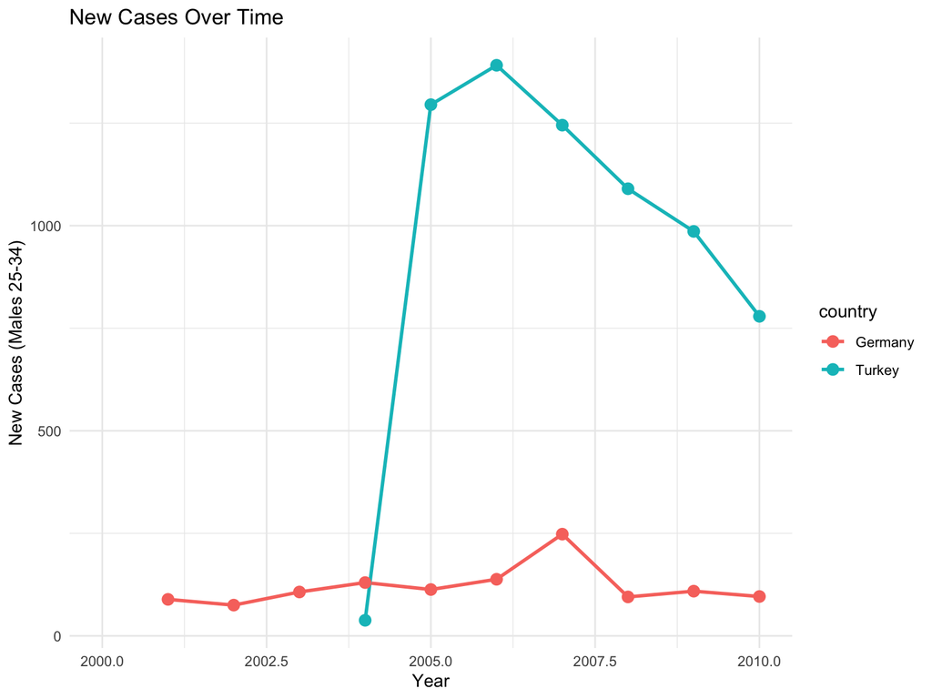

```r
data <-M1_results
ggplot(data, aes(x = year, y = new_sp_m2534, color = country, group = country)) +
  geom_line(size = 1) +
  geom_point(size = 3) +
  labs(title = "New Cases Over Time",
       x = "Year",
       y = "New Cases (Males 25-34)") +
  theme_minimal()
```

### Bar Chart

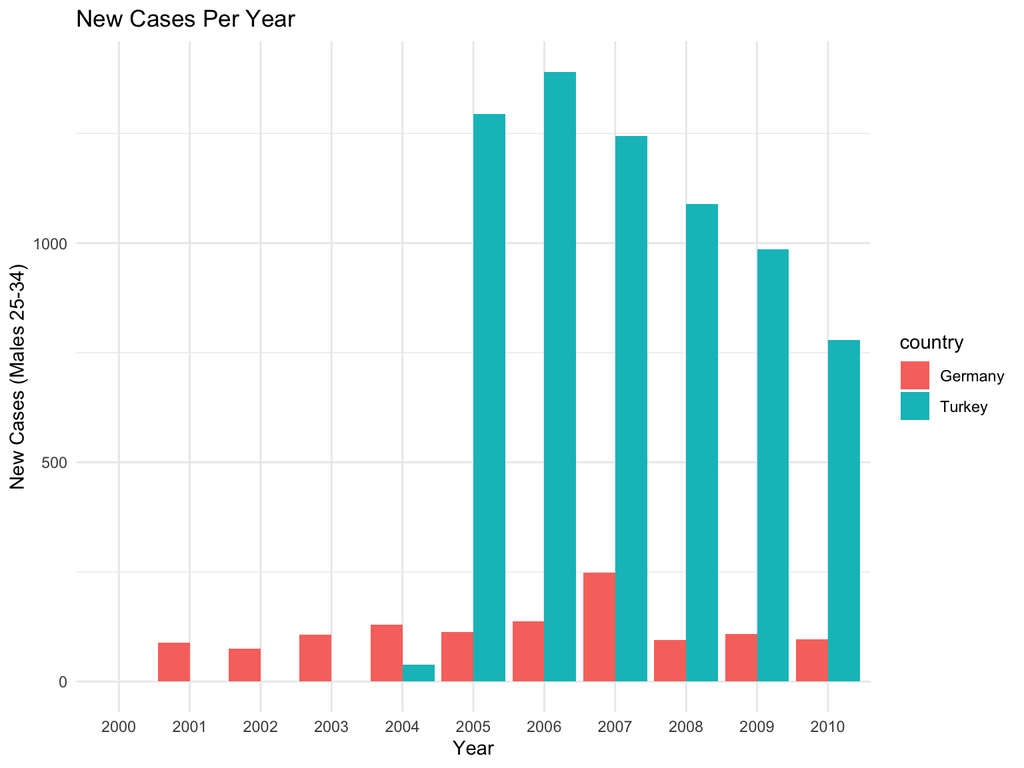

```r
ggplot(data, aes(x = as.factor(year), y = new_sp_m2534, fill = country)) +
  geom_bar(stat = "identity", position = "dodge") +
  labs(title = "New Cases Per Year",
       x = "Year",
       y = "New Cases (Males 25-34)") +
  theme_minimal()
```

### Trend

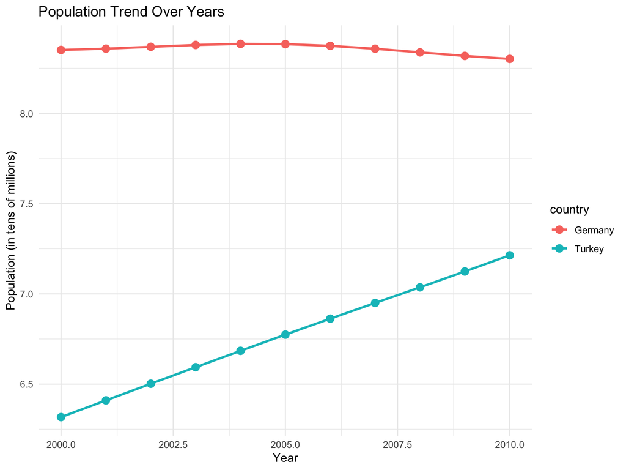

```r
ggplot(data, aes(x = year, y = population / 1e7, color = country, group = country)) +
  geom_line(size = 1) +
  geom_point(size = 3) +
  labs(title = "Population Trend Over Years",
       x = "Year",
       y = "Population (in tens of millions)") +
  theme_minimal()
```

### Scatter Plot

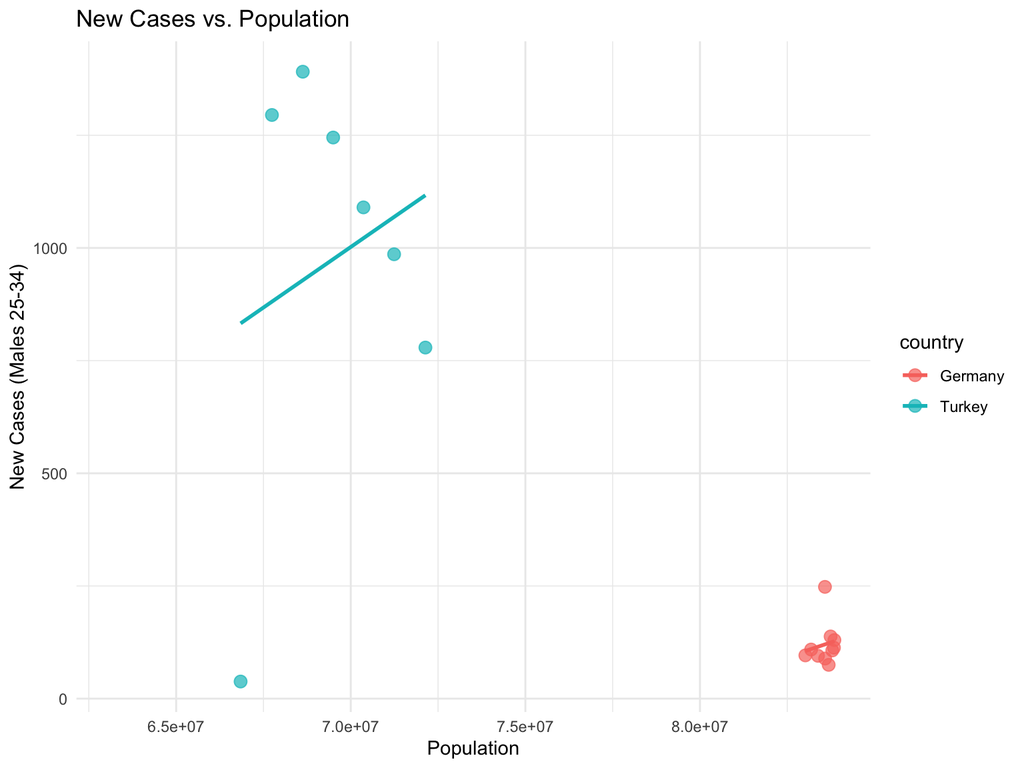

```r
ggplot(data, aes(x = population, y = new_sp_m2534, color = country)) +
  geom_point(size = 3, alpha = 0.7) +
  geom_smooth(method = "lm", se = FALSE) +
  labs(title = "New Cases vs. Population",
       x = "Population",
       y = "New Cases (Males 25-34)") +
  theme_minimal()
```

# 2.2 Veri Okuma

R dilinde veri okuma işlemleri, özellikle büyük veri setleriyle çalışırken oldukça önemlidir. `readr` ve `readxl` paketleri, bu işlemleri kolaylaştıran ve performans açısından optimize edilmiş paketlerdir. Şimdi bu paketlerle veri okuma işlemlerini inceleyelim.

## Veri oluşturma

Öncelikle kullanacağımız verileri oluşturalım. Ardından bu verileri ilgili dosya biçimlerinde kaydedelim.

```r
library(readr)
library(readxl)
library(haven)
library(jsonlite)
library(writexl)
library(data.table)
# Örnek veri seti oluşturma
ornek_veri <- data.frame(
  id = 1:5,
  name = c("Ali", "Veli", "Ayse", "Fatma", "Mehmet"),
  age = c(23, 45, 30, 19, 22),
  salary = c(3000, 4000, 2500, 3500, 2800),
  gender = c("M", "M", "F", "F", "M"),
  stringsAsFactors = FALSE
)
```

```r
# Dosyaları kaydetme
write.csv(ornek_veri, "ornek_veri.csv", row.names = FALSE)
write.table(ornek_veri, "ornek_veri.txt", row.names = FALSE, sep = "\t")
write_xlsx(ornek_veri, "ornek_veri.xlsx")
write_sav(ornek_veri, "ornek_veri.sav")
write_json(ornek_veri, "ornek_veri.json")
```

## readr Paketi ile Veri Okuma

`readr` paketi, metin tabanlı dosyaları (CSV, TXT, vb.) hızlı ve verimli bir şekilde okumak için kullanılır. `base R` fonksiyonlarına göre daha hızlıdır ve otomatik veri tipi tahmini yapar.

## CSV Dosyası Okuma

```r
# CSV dosyasını okuma
data_csv <- read_csv("ornek_veri.csv")
# Veriyi inceleme
print(data_csv)
```

```
## # A tibble: 5 × 5
##      id name     age salary gender
##   <dbl> <chr>  <dbl>  <dbl> <chr>
## 1     1 Ali       23   3000 M
## 2     2 Veli      45   4000 M
## 3     3 Ayse      30   2500 F
## 4     4 Fatma     19   3500 F
## 5     5 Mehmet    22   2800 M
```

```r
str(data_csv)
```

```
## spc_tbl_ [5 × 5] (S3: spec_tbl_df/tbl_df/tbl/data.frame)
##  $ id    : num [1:5] 1 2 3 4 5
##  $ name  : chr [1:5] "Ali" "Veli" "Ayse" "Fatma" ...
##  $ age   : num [1:5] 23 45 30 19 22
##  $ salary: num [1:5] 3000 4000 2500 3500 2800
##  $ gender: chr [1:5] "M" "M" "F" "F" ...
##  - attr(*, "spec")=
##   .. cols(
##   ..   id = col_double(),
##   ..   name = col_character(),
##   ..   age = col_double(),
##   ..   salary = col_double(),
##   ..   gender = col_character()
##   .. )
##  - attr(*, "problems")=<externalptr>
```

## TXT Dosyası Okuma

```r
# TXT dosyasını okuma
data_txt <- read_delim("ornek_veri.txt", delim = "\t")
# Veriyi inceleme
print(data_txt)
```

```
## # A tibble: 5 × 5
##      id name     age salary gender
##   <dbl> <chr>  <dbl>  <dbl> <chr>
## 1     1 Ali       23   3000 M
## 2     2 Veli      45   4000 M
## 3     3 Ayse      30   2500 F
## 4     4 Fatma     19   3500 F
## 5     5 Mehmet    22   2800 M
```

```r
str(data_txt)
```

```
## spc_tbl_ [5 × 5] (S3: spec_tbl_df/tbl_df/tbl/data.frame)
##  $ id    : num [1:5] 1 2 3 4 5
##  $ name  : chr [1:5] "Ali" "Veli" "Ayse" "Fatma" ...
##  $ age   : num [1:5] 23 45 30 19 22
##  $ salary: num [1:5] 3000 4000 2500 3500 2800
##  $ gender: chr [1:5] "M" "M" "F" "F" ...
##  - attr(*, "spec")=
##   .. cols(
##   ..   id = col_double(),
##   ..   name = col_character(),
##   ..   age = col_double(),
##   ..   salary = col_double(),
##   ..   gender = col_character()
##   .. )
##  - attr(*, "problems")=<externalptr>
```

## readr Fonksiyonları

- `read_csv()`: CSV dosyalarını okur.  
- `read_delim()`: Özel bir ayraç (delimiter) kullanarak dosyaları okur.  
- `read_table()`: Sabit genişlikteki dosyaları okur.

## readxl Paketi ile Excel Dosyalarını Okuma

`readxl` paketi, Excel dosyalarını (`.xls` ve `.xlsx`) okumak için kullanılır. Excel dosyalarındaki farklı sayfaları ve hücre aralıklarını okumayı destekler.

## Excel Dosyası Okuma

```r
# Excel dosyasını okuma
data_excel <- read_excel("ornek_veri.xlsx", sheet = 1)  # 1. sayfayı okur

# Veriyi inceleme
print(data_excel)
```

```
## # A tibble: 5 × 5
##      id name     age salary gender
##   <dbl> <chr>  <dbl>  <dbl> <chr>
## 1     1 Ali       23   3000 M
## 2     2 Veli      45   4000 M
## 3     3 Ayse      30   2500 F
## 4     4 Fatma     19   3500 F
## 5     5 Mehmet    22   2800 M
```

```r
str(data_excel)
```

```
## tibble [5 × 5] (S3: tbl_df/tbl/data.frame)
##  $ id    : num [1:5] 1 2 3 4 5
##  $ name  : chr [1:5] "Ali" "Veli" "Ayse" "Fatma" ...
##  $ age   : num [1:5] 23 45 30 19 22
##  $ salary: num [1:5] 3000 4000 2500 3500 2800
##  $ gender: chr [1:5] "M" "M" "F" "F" ...
```

## `readxl` Fonksiyonları

- `read_excel()`: Excel dosyalarını okur.  
- `excel_sheets()`: Excel dosyasındaki sayfaların isimlerini listeler.

```r
# Belirli bir hücre aralığını okuma
data_range <- read_excel("ornek_veri.xlsx", range = "A1:C10")

# Veriyi inceleme
print(data_range)
```

```
## # A tibble: 9 × 3
##      id name     age
##   <dbl> <chr>  <dbl>
## 1     1 Ali       23
## 2     2 Veli      45
## 3     3 Ayse      30
## 4     4 Fatma     19
## 5     5 Mehmet    22
## 6    NA <NA>      NA
## 7    NA <NA>      NA
## 8    NA <NA>      NA
## 9    NA <NA>      NA
```

```r
str(data_range)
```

```
## tibble [9 × 3] (S3: tbl_df/tbl/data.frame)
##  $ id  : num [1:9] 1 2 3 4 5 NA NA NA NA
##  $ name: chr [1:9] "Ali" "Veli" "Ayse" "Fatma" ...
##  $ age : num [1:9] 23 45 30 19 22 NA NA NA NA
```

## data.table

`data.table` paketi, büyük veri setlerini hızlı bir şekilde okumak ve manipüle etmek için kullanılır.

```r
# CSV dosyasını okuma
data_dt <- fread("ornek_veri.csv")

# Veriyi inceleme
print(data_dt)
```

```
##       id   name   age salary gender
##    <int> <char> <int>  <int> <char>
## 1:     1    Ali    23   3000      M
## 2:     2   Veli    45   4000      M
## 3:     3   Ayse    30   2500      F
## 4:     4  Fatma    19   3500      F
## 5:     5 Mehmet    22   2800      M
```

```r
str(data_dt)
```

```
## Classes 'data.table' and 'data.frame':   5 obs. of  5 variables:
##  $ id    : int  1 2 3 4 5
##  $ name  : chr  "Ali" "Veli" "Ayse" "Fatma" ...
##  $ age   : int  23 45 30 19 22
##  $ salary: int  3000 4000 2500 3500 2800
##  $ gender: chr  "M" "M" "F" "F" ...
##  - attr(*, ".internal.selfref")=<externalptr>
```

## haven Paketi

`haven` paketi, SPSS, SAS ve Stata gibi istatistiksel yazılımların dosya formatlarını okumak için kullanılır.

```r
# SPSS dosyasını okuma
data_spss <- read_sav("ornek_veri.sav")

# Veriyi inceleme
print(data_spss)
```

```
## # A tibble: 5 × 5
##      id name     age salary gender
##   <dbl> <chr>  <dbl>  <dbl> <chr>
## 1     1 Ali       23   3000 M
## 2     2 Veli      45   4000 M
## 3     3 Ayse      30   2500 F
## 4     4 Fatma     19   3500 F
## 5     5 Mehmet    22   2800 M
```

```r
str(data_spss)
```

```
## tibble [5 × 5] (S3: tbl_df/tbl/data.frame)
##  $ id    : num [1:5] 1 2 3 4 5
##   ..- attr(*, "format.spss")= chr "F8.0"
##  $ name  : chr [1:5] "Ali" "Veli" "Ayse" "Fatma" ...
##   ..- attr(*, "format.spss")= chr "A6"
##  $ age   : num [1:5] 23 45 30 19 22
##   ..- attr(*, "format.spss")= chr "F8.2"
##  $ salary: num [1:5] 3000 4000 2500 3500 2800
##   ..- attr(*, "format.spss")= chr "F8.2"
##  $ gender: chr [1:5] "M" "M" "F" "F" ...
##   ..- attr(*, "format.spss")= chr "A1"
```

## jsonlite Paketi

`jsonlite` paketi, JSON formatındaki dosyaları okumak ve işlemek için kullanılır.

```r
# JSON dosyasını okuma
data_json <- fromJSON("ornek_veri.json")

# Veriyi inceleme
print(data_json)
```

```
##   id   name age salary gender
## 1  1    Ali  23   3000      M
## 2  2   Veli  45   4000      M
## 3  3   Ayse  30   2500      F
## 4  4  Fatma  19   3500      F
## 5  5 Mehmet  22   2800      M
```

```r
str(data_json)
```

```
## 'data.frame':    5 obs. of  5 variables:
##  $ id    : int  1 2 3 4 5
##  $ name  : chr  "Ali" "Veli" "Ayse" "Fatma" ...
##  $ age   : int  23 45 30 19 22
##  $ salary: int  3000 4000 2500 3500 2800
##  $ gender: chr  "M" "M" "F" "F" ...
```

## Tüm Paketlerin Bir Arada Kullanımı

Aşağıdaki örnekte, `readr`, `readxl`, `data.table`, `haven` ve `jsonlite` paketlerini kullanarak farklı dosya formatlarını okuyoruz:

```r
# CSV dosyasını okuma (readr)
data_csv <- read_csv("ornek_veri.csv")
# Excel dosyasını okuma (readxl)
data_excel <- read_excel("ornek_veri.xlsx", sheet = 1)

# CSV dosyasını okuma (data.table)
data_dt <- fread("ornek_veri.csv")

# SPSS dosyasını okuma (haven)
data_spss <- read_sav("ornek_veri.sav")

# JSON dosyasını okuma (jsonlite)
data_json <- fromJSON("ornek_veri.json")
```

```r
# Verileri inceleme
print(data_csv)
```

```
## # A tibble: 5 × 5
##      id name     age salary gender
##   <dbl> <chr>  <dbl>  <dbl> <chr>
## 1     1 Ali       23   3000 M
## 2     2 Veli      45   4000 M
## 3     3 Ayse      30   2500 F
## 4     4 Fatma     19   3500 F
## 5     5 Mehmet    22   2800 M
```

```r
print(data_excel)
```

```
## # A tibble: 5 × 5
##      id name     age salary gender
##   <dbl> <chr>  <dbl>  <dbl> <chr>
## 1     1 Ali       23   3000 M
## 2     2 Veli      45   4000 M
## 3     3 Ayse      30   2500 F
## 4     4 Fatma     19   3500 F
## 5     5 Mehmet    22   2800 M
```

```r
print(data_dt)
```

```
##       id   name   age salary gender
##    <int> <char> <int>  <int> <char>
## 1:     1    Ali    23   3000      M
## 2:     2   Veli    45   4000      M
## 3:     3   Ayse    30   2500      F
## 4:     4  Fatma    19   3500      F
## 5:     5 Mehmet    22   2800      M
```

```r
print(data_spss)
```

```
## # A tibble: 5 × 5
##      id name     age salary gender
##   <dbl> <chr>  <dbl>  <dbl> <chr>
## 1     1 Ali       23   3000 M
## 2     2 Veli      45   4000 M
## 3     3 Ayse      30   2500 F
## 4     4 Fatma     19   3500 F
## 5     5 Mehmet    22   2800 M
```

```r
print(data_json)
```

```
##   id   name age salary gender
## 1  1    Ali  23   3000      M
## 2  2   Veli  45   4000      M
## 3  3   Ayse  30   2500      F
## 4  4  Fatma  19   3500      F
## 5  5 Mehmet  22   2800      M
```

## Özet

- **`readr`**: Metin tabanlı dosyaları hızlı bir biçimde okumak içindir
- **`readxl`**: Excel dosyalarını okumak için kullanışlıdır.
- **`data.table`**: Büyük veri setlerini okumak ve manipüle etmek içindir.
- **`haven`**: SPSS, SAS ve Stata gibi istatistiksel yazılımların dosya biçimlerini okumak için kullanılır.
- **`jsonlite`**: JSON formatındaki dosyaları okumak ve işlemek için kullanışlıdır.

Bu paketler, farklı dosya formatlarını okumak ve veri analizi sürecine hazır hale getirmek için oldukça kullanışlıdır. İhtiyaca göre doğru paketi seçerek veri okuma işlemlerinizi kolaylaştırabilirsiniz.

# 2.3 Veri Yapıları

R dilinde veri yapıları, veri analizi ve manipülasyonu sürecinde büyük önem taşır. Veri yapıları oldukça esnektir ve farklı veri türlerini saklamak ve işlemek için çeşitli veri yapıları sunar. Bu yapılar, veri analizi, istatistik, makine öğrenimi ve veri görselleştirme gibi birçok alanda kullanılır. En yaygın kullanılan veri yapıları `data.frame`, `tibble` ve `list`’dir. Bu yapıların her biri farklı durumlarda kullanılır ve kendine özgü avantajlara sahiptir. Aşağıda R’nin temel veri yapıları detaylıca açıklanmış ve her biri örneklerle gösterilmiştir.

## Vektör (Vector)

Vektörler, aynı türdeki verileri içeren bir veri yapısıdır. R’de en temel veri yapısıdır.

**Özellikler:**  
- Tek tip veri içerir (numeric, character, logical vb.).  
- 1 boyutludur.  
- Elemanlara indeksleme ile erişilebilir (`[ ]`).

**Oluşturma ve Kullanım**

```r
# Numeric vektör
vec_numeric <- c(1, 2, 3, 4, 5)

# Character vektör
vec_char <- c("A", "B", "C", "D")

# Logical vektör
vec_logical <- c(TRUE, FALSE, TRUE, TRUE)

# Elemanlara erişim
vec_numeric[2]  # 2. elemanı alır
```

```
## [1] 2
```

```r
vec_char[c(1, 3)]  # 1. ve 3. elemanı alır
```

```
## [1] "A" "C"
```

```r
# Elemanları sıralama

fruits <- c("muz", "elma", "portakal", "ayva", "limon")
numbers <- c(13, 3, 5, 7, 20, 2)

sort(fruits)  # Sort a string
```

```
## [1] "ayva"     "elma"     "limon"    "muz"      "portakal"
```

```r
sort(numbers) # Sort numbers
```

```
## [1]  2  3  5  7 13 20
```

```r
fruits[c(-2)] <- "kiraz"
fruits
```

```
## [1] "kiraz" "elma"  "kiraz" "kiraz" "kiraz"
```

**Kullanım Yerleri ve Güçlü Yanları:**  
- Tek tip veri içeren verileri saklamak için idealdir.  
- Matematiksel işlemler ve vektörel işlemler için çok hızlıdır.  
- Basit diziler ve listeler için uygundur.

## Matris (Matrix)

Matrisler, aynı türde verileri içeren 2 boyutlu veri yapılarıdır.

**Özellikler:**  
- Satır ve sütun yapısına sahiptir.  
- Elemanlara `[row, col]` ile erişilir.

**Oluşturma ve Kullanım:**

```r
# 3x3 numeric matris
mat <- matrix(1:9, nrow = 3, byrow = TRUE)
mat
```

```
##      [,1] [,2] [,3]
## [1,]    1    2    3
## [2,]    4    5    6
## [3,]    7    8    9
```

```r
# Elemanlara erişim
mat[1, 2]  # 1. satır, 2. sütun elemanı
```

```
## [1] 2
```

```r
mat[, 2]  # 2. sütundaki tüm elemanlar
```

```
## [1] 2 5 8
```

```r
mat[2, ]  # 2. satırdaki tüm elemanlar
```

```
## [1] 4 5 6
```

**Kullanım Yerleri ve Güçlü Yanları:**  
- Matematiksel hesaplamalar ve doğrusal cebir işlemleri için idealdir.  
- Veri analizinde ve görüntü işlemede kullanılır.

## Dizi (Array)

Diziler, matrise benzer ancak 2’den fazla boyuta sahip olabilir.

**Özellikler:**  
- Birden fazla boyuta sahiptir (3D, 4D vb.).  
- Elemanlara `[dim1, dim2, dim3]` ile erişilir.

**Oluşturma ve Kullanım:**

```r
# 3x3x2 boyutunda bir dizi oluşturma
arr <- array(1:18, dim = c(3, 3, 2))

# Elemanlara erişim
arr[1, 2, 1]  # 1. katman, 1. satır, 2. sütun elemanı
```

```
## [1] 4
```

**Kullanım Yerleri ve Güçlü Yanları:**  
- Çok boyutlu veri analizi için kullanılır.  
- İstatistiksel analizlerde ve makine öğreniminde kullanılır.

## Faktör (Factor)

Faktörler, kategorik verileri saklamak için kullanılır.

**Özellikler:**  
- Sınırlı ve tekrar eden kategorileri içerir.  
- R, faktör değişkenlerini “levels” olarak saklar.

**Oluşturma ve Kullanım:**

```r
# Faktör değişken oluşturma
colors <- factor(c("Red", "Blue", "Green", "Red", "Blue"))

# Faktör seviyelerini görüntüleme
levels(colors)
```

```
## [1] "Blue"  "Green" "Red"
```

```r
# Faktörlerin sayısal karşılıklarını alma
as.numeric(colors)
```

```
## [1] 3 1 2 3 1
```

**Kullanım Yerleri ve Güçlü Yanları:**  
- Kategorik verileri analiz etmek için kullanılır.  
- Grafiklerde ve istatistiksel analizlerde performans sağlar.

## Liste (List)

Listeler, farklı türden verileri bir arada saklayabilir.

**Özellikler:**  
- İçinde farklı veri yapıları (vektör, matris, veri çerçevesi vb.) bulunabilir.  
- Elemanlara `$` veya `[[ ]]` ile erişilir.

**Oluşturma ve Kullanım:**

```r
# Farklı türde veri içeren bir liste oluşturma
my_list <- list("elma", "armut", "ayva")

# Elemanlara erişim
my_list[2] # "armut"
```

```
## [[1]]
## [1] "armut"
```

```r
"elma" %in% my_list # True
```

```
## [1] TRUE
```

```r
length(my_list) # 3
```

```
## [1] 3
```

```r
my_list[1] <- "karadut"

append(my_list, "portakal")
```

```
## [[1]]
## [1] "karadut"
##
## [[2]]
## [1] "armut"
##
## [[3]]
## [1] "ayva"
##
## [[4]]
## [1] "portakal"
```

```r
my_list <- append(my_list, "muz", after = 2)

my_list
```

```
## [[1]]
## [1] "karadut"
##
## [[2]]
## [1] "armut"
##
## [[3]]
## [1] "muz"
##
## [[4]]
## [1] "ayva"
```

**Kullanım Yerleri ve Güçlü Yanları:** - Farklı veri türlerini saklamak için idealdir. - JSON ve XML veri yapıları ile çalışırken kullanılır.

## Veri Çerçevesi (Data Frame)

Veri çerçeveleri, farklı türde sütunları olan tablo formatında bir veri yapısıdır.

**Özellikler:**  
- Satır ve sütunlardan oluşur.  
- Her sütun farklı veri türü içerebilir.  
- Elemanlara `[row, col]` veya `$` ile erişilebilir.

**Oluşturma ve Kullanım:**

```r
# Örnek veri çerçevesi oluşturma
df <- data.frame(
  Name = c("Ali", "Ayşe", "Mehmet"),
  Age = c(25, 30, 22),
  Score = c(90, 85, 88)
)

# Elemanlara erişim
df$Name  # Tüm isimleri alır
```

```
## [1] "Ali"    "Ayşe"   "Mehmet"
```

```r
df[2, ]  # 2. satırı alır
```

```
##   Name Age Score
## 2 Ayşe  30    85
```

```r
df[df$Age > 25, ]  # Yaşı 25'ten büyük olanları filtreler
```

```
##   Name Age Score
## 2 Ayşe  30    85
```

**Kullanım Yerleri ve Güçlü Yanları:**  
- Veri analizi ve veri işleme için en yaygın kullanılan yapı.  
- Büyük veri kümeleriyle çalışmak için idealdir.

## Tibble (tibble)

Tibble, veri çerçevesinin (data frame) geliştirilmiş bir versiyonudur ve **tidyverse** paketinde bulunur.

**Oluşturma ve Kullanım:**

```r
# Gerekli paketi yükleyelim
library(dplyr)
library(tibble)

# Tibble oluşturma
tb <- tibble(
  Name = c("Ali", "Ayşe", "Mehmet"),
  Age = c(25, 30, 22),
  Score = c(90, 85, 88)
)

# Elemanlara erişim
tb$Name  # Tüm isimleri alır
```

```
## [1] "Ali"    "Ayşe"   "Mehmet"
```

```r
tb[2, ]  # 2. satırı alır
```

```
## # A tibble: 1 × 3
##   Name    Age Score
##   <chr> <dbl> <dbl>
## 1 Ayşe     30    85
```

```r
tb %>% filter(Age > 25)  # Yaşı 25'ten büyük olanları filtreler
```

```
## # A tibble: 1 × 3
##   Name    Age Score
##   <chr> <dbl> <dbl>
## 1 Ayşe     30    85
```

**Kullanım Yerleri ve Güçlü Yanları:**  
- Büyük veri kümeleriyle çalışırken daha hızlıdır.  
- Daha düzenli bir çıktı formatı sunar.  
- dplyr ve diğer tidyverse paketleriyle entegrasyonu kolaydır.  
- Tibble, klasik veri çerçevesine göre daha kullanıcı dostu ve modern bir alternatiftir.

## Özet

| Veri Yapısı | Boyut | Veri Türü | Kullanım Alanları |
| --- | --- | --- | --- |
| **Vektör** | 1D | Tek tip | Basit diziler, matematiksel işlemler |
| **Matris** | 2D | Tek tip | Doğrusal cebir, matematiksel hesaplamalar |
| **Dizi (Array)** | 3D+ | Tek tip | Çok boyutlu veri analizi |
| **Faktör (Factor)** | 1D | Kategorik | Kategorik veri analizi |
| **Liste (List)** | 1D | Farklı tip | Karmaşık veri yapıları |
| **Veri Çerçevesi (Data Frame)** | 2D | Farklı tip | Veri analizi, istatistik |
| **Tibble** | 2D | Farklı tip | Tidyverse ile veri analizi, büyük veri işlemleri |

## data.frame

`data.frame`, R’ın temel veri yapılarından biridir. Tablo benzeri bir yapı sunar ve her sütun farklı bir veri tipine sahip olabilir.

**Örnek:**

```r
# data.frame oluşturma
df2 <- data.frame(
  id = 1:5,
  name = c("Ali", "Veli", "Ayşe", "Fatma", "Mehmet"),
  age = c(23, 45, 30, 19, 22),
  salary = c(3000, 4000, 2500, 3500, 2800),
  stringsAsFactors = FALSE
)

# data.frame'i inceleme
print(df2)
```

```
##   id   name age salary
## 1  1    Ali  23   3000
## 2  2   Veli  45   4000
## 3  3   Ayşe  30   2500
## 4  4  Fatma  19   3500
## 5  5 Mehmet  22   2800
```

```r
str(df2)
```

```
## 'data.frame':    5 obs. of  4 variables:
##  $ id    : int  1 2 3 4 5
##  $ name  : chr  "Ali" "Veli" "Ayşe" "Fatma" ...
##  $ age   : num  23 45 30 19 22
##  $ salary: num  3000 4000 2500 3500 2800
```

**Güçlü Yanları:**

- **Esneklik**: Her sütun farklı bir veri tipine sahip olabilir (sayısal, karakter, mantıksal, vb.).
- **Geniş Kullanım**: R’ın temel yapısı olduğu için birçok fonksiyon ve paket `data.frame` ile uyumludur.
- **Manipülasyon Kolaylığı**: Satır ve sütun bazında kolayca manipüle edilebilir.

**Kullanım Yerleri:**

- Temel veri analizi ve manipülasyonu.
- R’ın temel fonksiyonlarıyla çalışırken (örneğin, `lm()` ile lineer regresyon).

### tibble

`tibble`, `data.frame`’in modern bir alternatifidir ve `tidyverse` paket koleksiyonunun bir parçasıdır. `data.frame`’e göre daha kullanıcı dostu ve tutarlı bir yapı sunar.

```r
# tibble oluşturma

tb2 <- tibble(
  id = 1:5,
  name = c("Ali", "Veli", "Ayşe", "Fatma", "Mehmet"),
  age = c(23, 45, 30, 19, 22),
  salary = c(3000, 4000, 2500, 3500, 2800)
)

# tibble'ı inceleme
print(tb2)
```

```
## # A tibble: 5 × 4
##      id name     age salary
##   <int> <chr>  <dbl>  <dbl>
## 1     1 Ali       23   3000
## 2     2 Veli      45   4000
## 3     3 Ayşe      30   2500
## 4     4 Fatma     19   3500
## 5     5 Mehmet    22   2800
```

```r
str(tb2)
```

```
## tibble [5 × 4] (S3: tbl_df/tbl/data.frame)
##  $ id    : int [1:5] 1 2 3 4 5
##  $ name  : chr [1:5] "Ali" "Veli" "Ayşe" "Fatma" ...
##  $ age   : num [1:5] 23 45 30 19 22
##  $ salary: num [1:5] 3000 4000 2500 3500 2800
```

**Güçlü Yanları:**  
- **Okunabilirlik**: Büyük veri setlerini konsolda daha okunabilir şekilde gösterir (ilk 10 satırı gösterir).  
- **Tutarlılık**: `data.frame`’e göre daha tutarlı davranışlar sergiler (örneğin, otomatik sütun ismi düzeltme).  
- **Modern Fonksiyonlar**: `dplyr` ve `tidyr` gibi `tidyverse` paketleriyle tam uyumludur.

**Kullanım Yerleri:**  
- `tidyverse` paketleriyle çalışırken.  
- Büyük veri setleri üzerinde çalışırken.  
- Veri manipülasyonu ve temizleme işlemlerinde.

### list

`list`, farklı veri tiplerini ve yapılarını bir arada tutabilen esnek bir veri yapısıdır. Her eleman farklı bir veri tipine veya yapısına sahip olabilir.

```r
# list oluşturma
my_list2 <- list(
  name = "Ali",
  age = 23,
  scores = c(85, 90, 78),
  details = list(city = "Ankara", country = "Turkey")
)

# list'i inceleme
print(my_list2)
```

```
## $name
## [1] "Ali"
##
## $age
## [1] 23
##
## $scores
## [1] 85 90 78
##
## $details
## $details$city
## [1] "Ankara"
##
## $details$country
## [1] "Turkey"
```

```r
str(my_list2)
```

```
## List of 4
##  $ name   : chr "Ali"
##  $ age    : num 23
##  $ scores : num [1:3] 85 90 78
##  $ details:List of 2
##   ..$ city   : chr "Ankara"
##   ..$ country: chr "Turkey"
```

**Güçlü Yanları:**  
- **Esneklik**: Farklı veri tiplerini ve yapılarını bir arada tutabilir.  
- **Hiyerarşik Yapı**: İç içe listeler oluşturarak karmaşık veri yapılarını temsil edebilir.  
- **Geniş Kullanım**: Özellikle JSON veya XML gibi hiyerarşik veri yapılarıyla çalışırken kullanışlıdır.

**Kullanım Yerleri:**  
- Farklı veri tiplerini bir arada tutmak gerektiğinde.  
- JSON veya XML gibi hiyerarşik veri yapılarını temsil ederken.  
- Fonksiyonlardan birden fazla çıktı döndürülürken.

data.frame, tibble ve liste karşılaştırma ve özet

| Özellik | `data.frame` | `tibble` | `list` |
| --- | --- | --- | --- |
| **Esneklik** | Sütunlar farklı tiplerde olabilir | Sütunlar farklı tiplerde olabilir | Her eleman farklı tip/yapıda olabilir |
| **Okunabilirlik** | Büyük veri setlerinde zor | Büyük veri setlerinde daha iyi | Karmaşık yapılar okunabilir |
| **Manipülasyon** | Temel R fonksiyonlarıyla uyumlu | `tidyverse` ile uyumlu | Esnek, ancak manipülasyon zor |
| **Kullanım Yeri** | Temel analizler | Modern veri analizi ve temizleme | Karmaşık ve hiyerarşik veriler |

**Tüm Yapıların Bir Arada Kullanımı** Aşağıdaki örnekte, `data.frame`, `tibble` ve `list` yapılarını bir arada kullanıyoruz:

```r
# data.frame oluşturma
df <- data.frame(
  id = 1:3,
  name = c("Ali", "Veli", "Ayşe"),
  age = c(23, 45, 30)
)

# tibble oluşturma
library(tibble)
tb <- tibble(
  id = 4:6,
  name = c("Fatma", "Mehmet", "Zeynep"),
  age = c(19, 22, 29)
)

# list oluşturma
my_list <- list(
  data_frame = df,
  tibble = tb,
  description = "Bu bir örnek listedir."
)

# Listeyi inceleme
print(my_list)
```

```
## $data_frame
##   id name age
## 1  1  Ali  23
## 2  2 Veli  45
## 3  3 Ayşe  30
##
## $tibble
## # A tibble: 3 × 3
##      id name     age
##   <int> <chr>  <dbl>
## 1     4 Fatma     19
## 2     5 Mehmet    22
## 3     6 Zeynep    29
##
## $description
## [1] "Bu bir örnek listedir."
```

```r
str(my_list)
```

```
## List of 3
##  $ data_frame :'data.frame': 3 obs. of  3 variables:
##   ..$ id  : int [1:3] 1 2 3
##   ..$ name: chr [1:3] "Ali" "Veli" "Ayşe"
##   ..$ age : num [1:3] 23 45 30
##  $ tibble     : tibble [3 × 3] (S3: tbl_df/tbl/data.frame)
##   ..$ id  : int [1:3] 4 5 6
##   ..$ name: chr [1:3] "Fatma" "Mehmet" "Zeynep"
##   ..$ age : num [1:3] 19 22 29
##  $ description: chr "Bu bir örnek listedir."
```

Bu örnekte, `data.frame` ve `tibble` yapılarını bir `list` içinde birleştirerek karmaşık bir veri yapısı oluşturduk. Bu tür yapılar, özellikle farklı veri kaynaklarını bir arada tutmak gerektiğinde kullanışlıdır.

### Özet

- **`data.frame`**: Temel veri analizi için uygun, geniş kullanım alanına sahip.
- **`tibble`**: Modern veri analizi ve manipülasyonu için ideal, özellikle `tidyverse` ile çalışırken.
- **`list`**: Esnek ve hiyerarşik veri yapıları için kullanışlı, karmaşık verileri temsil etmek için ideal.

Bu veri yapılarını doğru şekilde kullanarak, R’da veri analizi ve manipülasyonu süreçlerinizi daha verimli hale getirebilirsiniz.

# 2.4 Veri Temizleme

## Giriş

R dilinde veri temizleme adımlarını eksik değerlerin tespiti ve yönetimi, aykırı değerlerin tespiti, veri tiplerinin dönüştürülmesi, format ayarlamaları ve dönüşümler ile filtreleme işlemlerini içeren bir veri temizleme sürecini adım adım gerçekleştireceğiz.

## Örnek Veri Seti

Öncelikle, örnek bir veri seti oluşturalım:

```r
# Gerekli kütüphaneleri yükleme
library(dplyr)
library(tidyr)

# Örnek veri seti oluşturma
set.seed(123)
data <- data.frame(
  id = 1:10,
  name = c("Ali", "Veli", NA, "Ayse", "Fatma", "Mehmet", "Zeynep", "Ahmet", "Huseyin", "Mustafa"),
  age = c(23, 45, 30, NA, 19, 22, 29, 35, 50, 100),
  salary = c(3000, 4000, 2500, 3500, NA, 2800, 3200, 4500, 5000, 10000),
  gender = c("M", "M", "F", "F", "F", "M", "F", "M", "M", "M"),
  V1 = c(NA, NA, 1, 2, 3, NA, 1, NA, NA, NA),
  V2 = c(NA, 0, NA, 1, 1, 2, 2, 2, 0, 1),
  stringsAsFactors = FALSE
)

print(data)
```

```
##    id    name age salary gender V1 V2
## 1   1     Ali  23   3000      M NA NA
## 2   2    Veli  45   4000      M NA  0
## 3   3    <NA>  30   2500      F  1 NA
## 4   4    Ayse  NA   3500      F  2  1
## 5   5   Fatma  19     NA      F  3  1
## 6   6  Mehmet  22   2800      M NA  2
## 7   7  Zeynep  29   3200      F  1  2
## 8   8   Ahmet  35   4500      M NA  2
## 9   9 Huseyin  50   5000      M NA  0
## 10 10 Mustafa 100  10000      M NA  1
```

Bu veri setinde:  
- `id`: Benzersiz kimlik numarası  
- `name`: Kişi ismi  
- `age`: Yaş  
- `salary`: Maaş  
- `gender`: Cinsiyet  
- `V1`: Bilinmeyen bir veri

## Eksik Değerlerin Tespiti ve Yönetimi

Eksik değerleri tespit etmek için `is.na()` fonksiyonunu kullanabiliriz. Eksik değerleri doldurmak veya kaldırmak için çeşitli yöntemler uygulayabiliriz.

```r
# Eksik değerleri tespit etme
sum(is.na(data))
```

```
## [1] 11
```

```r
# Her sütundaki eksik değer sayısını bulma
colSums(is.na(data))
```

```
##     id   name    age salary gender     V1     V2
##      0      1      1      1      0      6      2
```

```r
# Eksik değerleri ortalama ile doldurma (örneğin yaş için)
data$age[is.na(data$age)] <- mean(data$age, na.rm = TRUE)

# Eksik değerleri kaldırma (örneğin maaş için)
data <- data %>% drop_na(salary)

# Eksik değerleri medyan ile doldurma (örneğin V1 ve V2 için)
data$V1[is.na(data$V1)] <- median(data$V1, na.rm = TRUE)
data$V2[is.na(data$V2)] <- median(data$V2, na.rm = TRUE)

print(data)
```

```
##   id    name       age salary gender V1 V2
## 1  1     Ali  23.00000   3000      M  1  1
## 2  2    Veli  45.00000   4000      M  1  0
## 3  3    <NA>  30.00000   2500      F  1  1
## 4  4    Ayse  39.22222   3500      F  2  1
## 5  6  Mehmet  22.00000   2800      M  1  2
## 6  7  Zeynep  29.00000   3200      F  1  2
## 7  8   Ahmet  35.00000   4500      M  1  2
## 8  9 Huseyin  50.00000   5000      M  1  0
## 9 10 Mustafa 100.00000  10000      M  1  1
```

## Tamamen Rastgele Eksik Değer

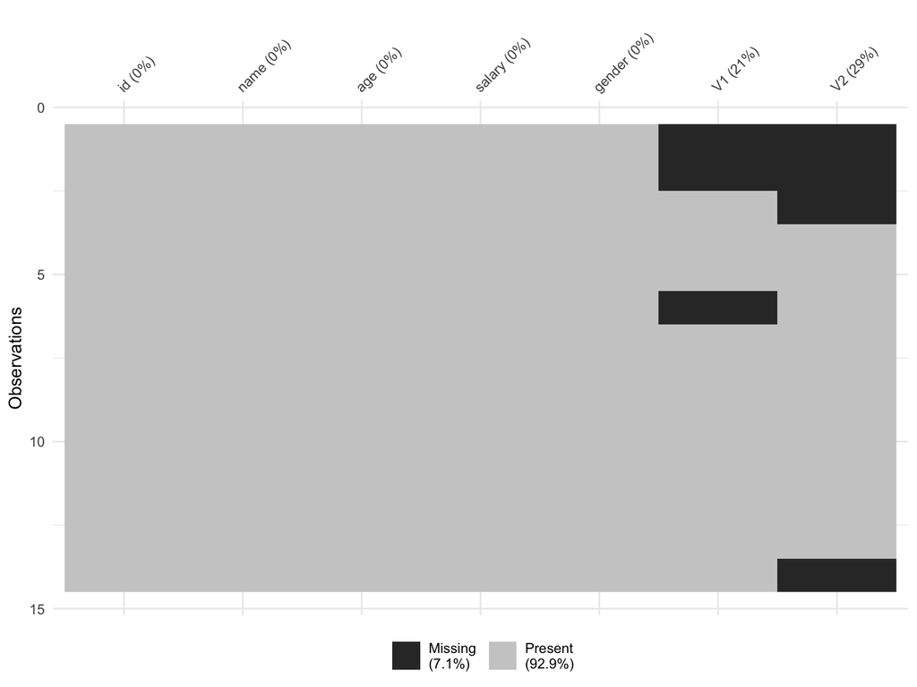

```r
# Load required libraries
library(naniar) # For missing data visualization
library(missForest) # For statistical MCAR test
library(MissMech)

# Define the dataset
data <- data.frame(
  id = 1:14,
  name = c("Ali", "Veli", "Canan", "Ayşe", "Fatma",
           "Mehmet", "Zeynep", "Ahmet", "Hüseyin",
           "Mustafa", "Seyran", "Suna", "Defne", "Su"),
  age = c(23, 45, 30, 25, 19, 22, 29,
          35, 25, 20, 25, 26, 20, 21),
  salary = c(3000, 4000, 2500, 3500, 3000, 2800, 3200,
             4500, 5000, 4000, 5000, 2700,3100,3000),
  gender = c("M", "M", "F", "F", "F", "M", "F",
             "M", "M", "M","F", "F","F", "F"),
  V1 = c(NA, NA, 1, 2, 3, NA, 1, 0, 0, 0, 1, 1, 2, 2),
  V2 = c(NA, NA, NA, 1, 1, 2, 2, 2, 0, 1, 1, 1, 2, NA),
  stringsAsFactors = FALSE
)

# Convert gender to numeric (M = 0, F = 1)
data$gender <- ifelse(data$gender == "M", 0, 1)
numeric_data <- data %>% select(-name)

# 1. Visualizing Missing Data
vis_miss(data)
```

```r
# 2. Little's MCAR Test (Checks if missingness is completely random)
print(TestMCARNormality(numeric_data,del.lesscases = 1))
```

```
## Call:
## TestMCARNormality(data = numeric_data, del.lesscases = 1)
##
## Number of Patterns:  3
##
## Total number of cases used in the analysis:  13
##
##  Pattern(s) used:
##           id   age   salary   gender   V1   V2   Number of cases
## group.1    1     1        1        1   NA   NA                 2
## group.2    1     1        1        1    1   NA                 2
## group.3    1     1        1        1    1    1                 9
##
##
##     Test of normality and Homoscedasticity:
##   -------------------------------------------
##
## Hawkins Test:
##
##     P-value for the Hawkins test of normality and homoscedasticity:  0.2490487
##
##     There is not sufficient evidence to reject normality
##     or MCAR at 0.05 significance level
```

```r
#mcar_test_result <- missForest::prodNA(data, noNA = 0) # No additional NA, just to ensure format
#print(MissMech::TestMCARNormality(mcar_test_result))

# 3. Checking for MAR (Correlation of missingness with other variables)
missing_V1 <- is.na(data$V1)
summary(lm(missing_V1 ~ age + salary + gender, data = data)) # If significant, suggests MAR
```

```
##
## Call:
## lm(formula = missing_V1 ~ age + salary + gender, data = data)
##
## Residuals:
##      Min       1Q   Median       3Q      Max
## -0.43122 -0.16486 -0.00501  0.24083  0.44537
##
## Coefficients:
##               Estimate Std. Error t value Pr(>|t|)
## (Intercept)  1.1197899  0.5343473   2.096  0.06254 .
## age          0.0136756  0.0129266   1.058  0.31497
## salary      -0.0002594  0.0001125  -2.305  0.04388 *
## gender      -0.6101425  0.1849165  -3.300  0.00802 **
## ---
## Signif. codes:  0 '***' 0.001 '**' 0.01 '*' 0.05 '.' 0.1 ' ' 1
##
## Residual standard error: 0.3085 on 10 degrees of freedom
## Multiple R-squared:  0.5962, Adjusted R-squared:  0.4751
## F-statistic: 4.922 on 3 and 10 DF,  p-value: 0.02365
```

```r
missing_V2 <- is.na(data$V2)
summary(lm(missing_V2 ~ age + salary + gender, data = data)) # If significant, suggests MAR
```

```
##
## Call:
## lm(formula = missing_V2 ~ age + salary + gender, data = data)
##
## Residuals:
##     Min      1Q  Median      3Q     Max
## -0.4463 -0.3173 -0.1142  0.2188  0.7785
##
## Coefficients:
##               Estimate Std. Error t value Pr(>|t|)
## (Intercept)  0.5775919  0.7681923   0.752    0.469
## age          0.0285243  0.0185836   1.535    0.156
## salary      -0.0002710  0.0001618  -1.675    0.125
## gender      -0.1420684  0.2658410  -0.534    0.605
##
## Residual standard error: 0.4435 on 10 degrees of freedom
## Multiple R-squared:  0.3115, Adjusted R-squared:  0.105
## F-statistic: 1.508 on 3 and 10 DF,  p-value: 0.2718
```

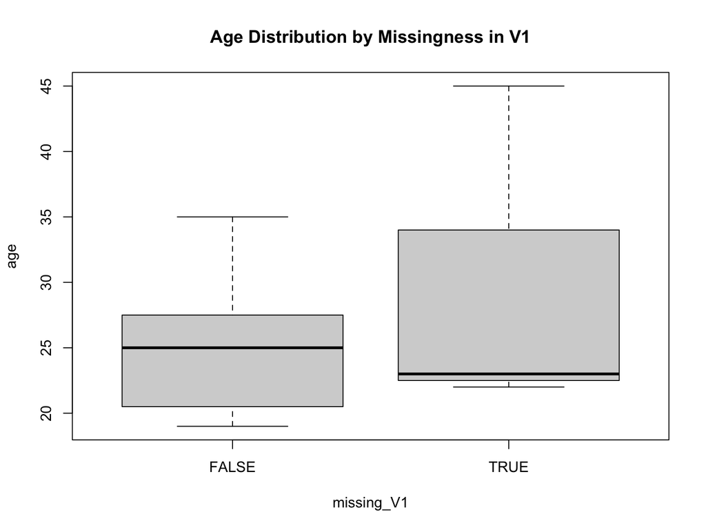

```r
# 4. Checking for MNAR (Pattern of missingness in V1 itself)
boxplot(age ~ missing_V1, data = data, main = "Age Distribution by Missingness in V1")
```

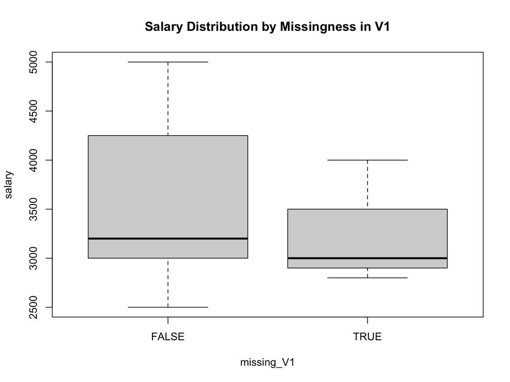

```r
boxplot(salary ~ missing_V1, data = data, main = "Salary Distribution by Missingness in V1")
```

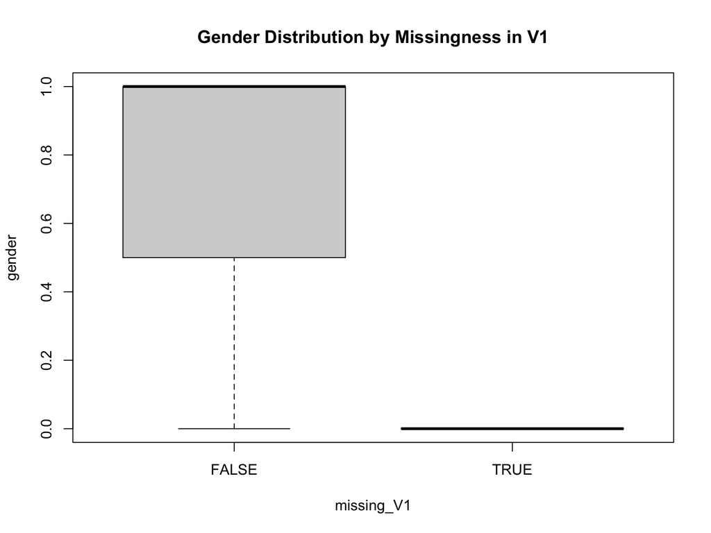

```r
boxplot(gender ~ missing_V1, data = data, main = "Gender Distribution by Missingness in V1")
```

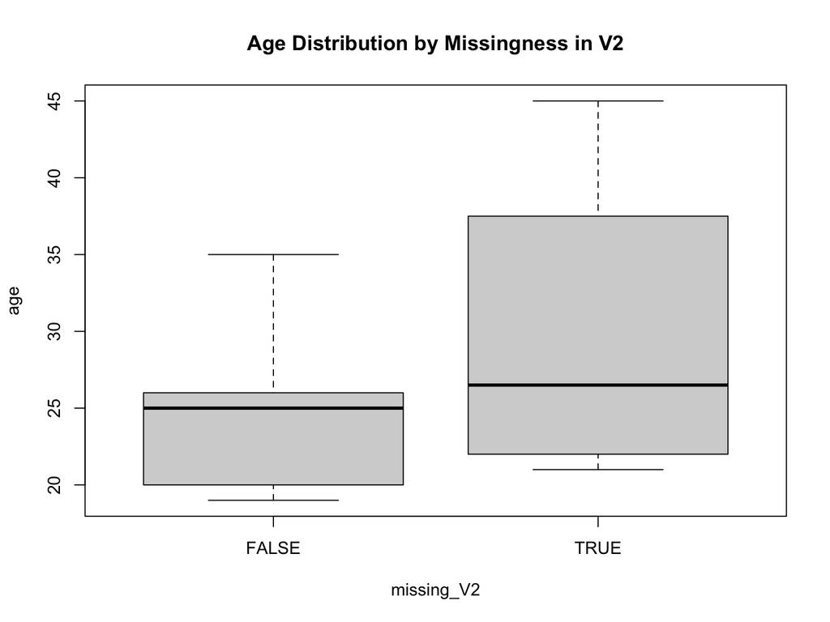

```r
boxplot(age ~ missing_V2, data = data, main = "Age Distribution by Missingness in V2")
```

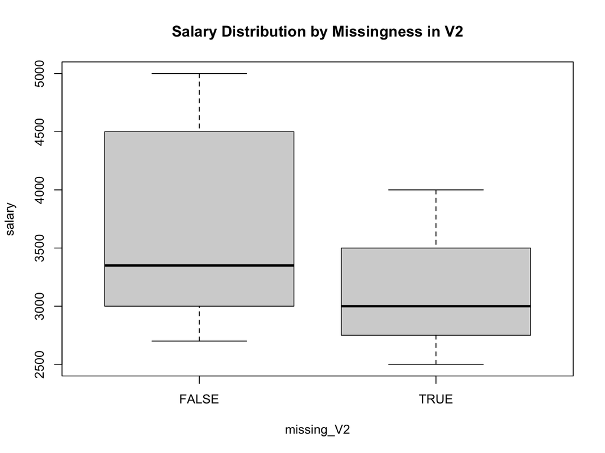

```r
boxplot(salary ~ missing_V2, data = data, main = "Salary Distribution by Missingness in V2")
```

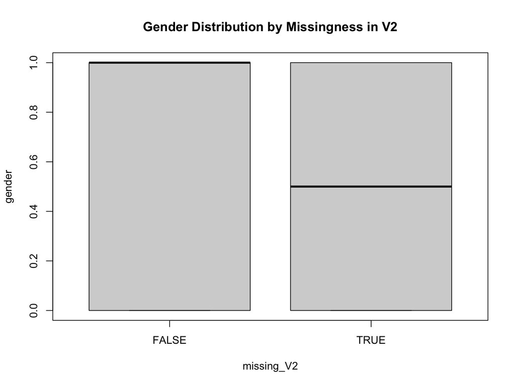

```r
boxplot(gender ~ missing_V2, data = data, main = "Gender Distribution by Missingness in V2")
```

## Aykırı Değerlerin Tespiti ve Yönetimi

Aykırı değerleri tespit etmek için kutu grafiği (boxplot) veya istatistiksel yöntemler kullanabiliriz. Örneğin, yaş sütunundaki aykırı değerleri tespit edelim.

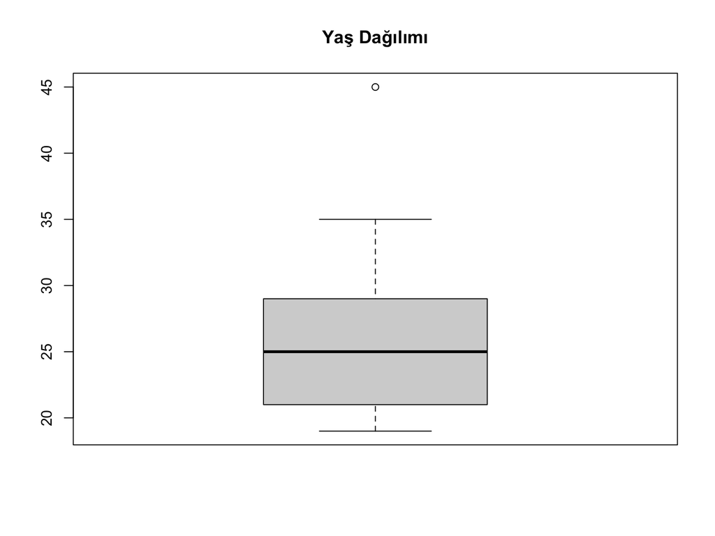

```r
# Yaş sütunu için kutu grafiği
boxplot(data$age, main="Yaş Dağılımı")
```

```r
# Aykırı değerleri tespit etme
Q1 <- quantile(data$age, 0.25)
Q3 <- quantile(data$age, 0.75)
IQR <- Q3 - Q1

lower_bound <- Q1 - 1.5 * IQR
upper_bound <- Q3 + 1.5 * IQR

outliers <- data$age < lower_bound | data$age > upper_bound
data$age[outliers] <- NA  # Aykırı değerleri NA ile değiştirme

# Aykırı değerleri kaldırma
data <- data %>% drop_na(age)

print(data)
```

```
##    id    name age salary gender V1 V2
## 1   1     Ali  23   3000      0 NA NA
## 2   3   Canan  30   2500      1  1 NA
## 3   4    Ayşe  25   3500      1  2  1
## 4   5   Fatma  19   3000      1  3  1
## 5   6  Mehmet  22   2800      0 NA  2
## 6   7  Zeynep  29   3200      1  1  2
## 7   8   Ahmet  35   4500      0  0  2
## 8   9 Hüseyin  25   5000      0  0  0
## 9  10 Mustafa  20   4000      0  0  1
## 10 11  Seyran  25   5000      1  1  1
## 11 12    Suna  26   2700      1  1  1
## 12 13   Defne  20   3100      1  2  2
## 13 14      Su  21   3000      1  2 NA
```

## Veri Tiplerinin Dönüştürülmesi ve Biçim Ayarlamaları

Veri tiplerini dönüştürmek ve format ayarlamaları yapmak için `as.` fonksiyonlarını kullanabiliriz. Örneğin, cinsiyet sütununu faktör tipine dönüştürelim.

```r
# Cinsiyet sütununu faktör tipine dönüştürme
data$gender <- as.factor(data$gender)

# Veri tiplerini kontrol etme
str(data)
```

```
## 'data.frame':    13 obs. of  7 variables:
##  $ id    : int  1 3 4 5 6 7 8 9 10 11 ...
##  $ name  : chr  "Ali" "Canan" "Ayşe" "Fatma" ...
##  $ age   : num  23 30 25 19 22 29 35 25 20 25 ...
##  $ salary: num  3000 2500 3500 3000 2800 3200 4500 5000 4000 5000 ...
##  $ gender: Factor w/ 2 levels "0","1": 1 2 2 2 1 2 1 1 1 2 ...
##  $ V1    : num  NA 1 2 3 NA 1 0 0 0 1 ...
##  $ V2    : num  NA NA 1 1 2 2 2 0 1 1 ...
```

## Dönüşümler ve Filtreleme İşlemleri (dplyr ile)

`dplyr` paketi ile veri dönüşümleri ve filtreleme işlemleri yapabiliriz. Örneğin, belirli bir yaş aralığındaki kişileri filtreleyelim ve maaşlarını artıralım.

```r
# Yaşı 20 ile 40 arasında olan kişileri filtreleme
filtered_data <- data %>% filter(age >= 20 & age <= 40)

# Maaşları %10 artırma
filtered_data <- filtered_data %>% mutate(salary = salary * 1.10)

print(filtered_data)
```

```
##    id    name age salary gender V1 V2
## 1   1     Ali  23   3300      0 NA NA
## 2   3   Canan  30   2750      1  1 NA
## 3   4    Ayşe  25   3850      1  2  1
## 4   6  Mehmet  22   3080      0 NA  2
## 5   7  Zeynep  29   3520      1  1  2
## 6   8   Ahmet  35   4950      0  0  2
## 7   9 Hüseyin  25   5500      0  0  0
## 8  10 Mustafa  20   4400      0  0  1
## 9  11  Seyran  25   5500      1  1  1
## 10 12    Suna  26   2970      1  1  1
## 11 13   Defne  20   3410      1  2  2
## 12 14      Su  21   3300      1  2 NA
```

## Sonuç

Bu adımlarla, R dilinde veri temizleme sürecini detaylı bir şekilde gerçekleştirdik. Eksik değerlerin tespiti ve yönetimi, aykırı değerlerin tespiti, veri tiplerinin dönüştürülmesi ve format ayarlamaları, dönüşümler ve filtreleme işlemleri gibi temel veri temizleme tekniklerini uyguladık. Bu adımlar, veri analizi sürecinde veri kalitesini artırmak için oldukça önemlidir.